# Modul 411

Datenstrukturen und Algorithmen

Julian Kaeser

Sven Schirmer

# 1 Willkommen (zurück) bei in Java

In der Informatiker-Welt läuft nichts ohne Datenstrukturen und Algorithmen. Eine einfache Bitmap-Datei beispielsweise besteht aus einer (meist) dreidimensionalen Tabelle bzw. Feld. Unkomprimierte Audio-Dateien enthalten ebenfalls Felder. In diesem Modul lernen Sie verschiedene komplexe Datenstrukturen und deren grundlegende Eigenschaften kennen. Mit diesem Wissen können Sie wichtige Entscheidungen für Ihre eigenen Software-Projekte treffen.

In diesem Modul werden wir mit der Programmiersprache Java SE 8 arbeiten. Vorausgesetzt werden gute Kenntnisse aus den Modulen 403 (Prozedurale Programmierung) und 226A+B (Objektorientierte Programmierung). Sie können frei wählen, mit welcher Entwicklungsumgebung Sie arbeiten. Bevorzugte Umgebungen sind Netbeans und Eclipse.

Zur Verwaltung der Datenstrukturen werden spezielle Funktionen bzw. Algorithmen benötigt. Wichtige Beispiele sind Such- und Sortier-Algorithmen. Wie immer in der Informatik gibt es verschiedene Wege, solche Algorithmen zu programmieren, und entsprechend kann die Laufzeit stark variieren. Sie lernen, einfache Sortier-Algorithmen selbst zu implementieren und deren Rechenzeit abzuschätzen.

Die meisten Programmiersprachen liefern häufig benötigte Datenstrukturen und die dazugehörigen Algorithmen gleich mit. Damit wird der Aufwand für die Implementierung und das Testen in der Software-Entwicklung massiv reduziert. In der Programmiersprache Java sind diese Datenstrukturen in der java.utils Bibliothek implementiert.

Abschliessend werden wichtige moderne Datenstrukturen und dafür benötigte Methoden vorgestellt. Sie kommunizieren mit Web-Services und lernen die wichtigsten Datenformate des Internets und deren Auswertefunktionen kennen.

## 1.1 Wichtige Hinweise

Programmieren lernt man nicht nur vom Zuhören, sondern insbesondere vom selbstständigen (und häufigen) Ausprobieren, Anwenden. Fehler machen gehört dazu, aus denen lernen Sie am meisten. Ihren Erfolg können Sie sichern, indem Sie alle Übungsaufgaben zu hause selbstständig nach den entsprechenden Lektionen bearbeiten. Übung macht den Meister!

Die Aufgaben sind normalerweise für Konsolen-Anwendungen gestellt, weil diese schneller zu erstellen sind. Insbesondere die erstellten Klassen späterer Aufgaben können Sie leicht in eigene *SWING* oder *Java-FX* GUIs einbinden.

Dokumentieren Sie Ihren Quellcode von Anfang an JavaDoc-kompatibel, wie im Beispiel beschrieben. Damit haben Sie später eine Chance, Ihre brillanten Ideen wieder zu verstehen :-)

```
/**
    Genius provides the answer to the question of Life, the Universe and everything
*/
public class Genius{

    /**
     * answers a question
     * @param question is the query
     * @return the answer to the question of Life, the Universe and everything
     */
    public int answerQuestion(String question){
        return 42;
    }
}
```

## 1.2 Handlungsziele nach ICT-Vorgaben (BiVo 2014)

1. **Für ein gegebenes Problem eine geeignete Datenstruktur definieren und mit den Mitteln einer Programmiersprache, wie Structs, Referenzen / Zeiger und Arrays umsetzen.**
- Kennt den Unterschied zwischen Wertevariablen und Referenzvariablen / Zeigervariablen.
- Kennt Sprachmittel einer Programmiersprache für das Deklarieren und das Arbeiten mit Werte- und Referenzvariablen.
- Kennt Konzept und Nutzen von verketteten Datenstrukturen.
- Kennt eine Notation für die Darstellung von verketteten Datenstrukturen.
2. **Ein Problem analysieren und einen geeigneten Algorithmus zur Lösung mit den Grundelementen Zuweisung, Verzweigung und Schleife entwerfen und mit Prozeduren und Funktionen umsetzen.**
- Kennt eine systematische Vorgehensweise für die Analyse eines Problems.
- Kennt die Grundelemente von Algorithmen und deren Umsetzung in einer Programmiersprache.
- Kennt die Sprachmittel einer Programmiersprache für das Deklarieren und Aufrufen von Funktionen und Prozeduren.
- Kennt Notationen um Algorithmen darzustellen wie z.B. Struktogrammen, PAP usw.
3. **Algorithmen und Datenstrukturen hinsichtlich Speicher- und Zeitkomplexität analysieren und dokumentieren.**
- Kennt Möglichkeiten zur Analyse von Zeit- und Speicherkomplexität von Algorithmen und Datenstrukturen.
- Kennt Komplexitätsklassen von Algorithmen (z.B. lineare, exponentielle Komplexität).
- Kennt Notationen zur Dokumentation der Speicher- und Zeitkomplexität eines Algorithmus.
4. **Ein komplexeres Problem auf kleinere Teilprobleme zurückführen und je nach Problemstellung Iteration oder Rekursion einsetzen.**
- Kennt ein Vorgehen bei der Aufteilung eines komplexen Problems in kleinere Teilprobleme.
- Kennt den Aufbau von iterativen Algorithmen.
- Kennt den Aufbau von rekursiven Algorithmen.
- Kennt Vor- und Nachteile sowie geeignete Einsatzgebiete des iterativen und des rekursiven Ansatzes.
5. **Abstrakte Datentypen, wie Liste, Set, Map etc. und die darauf definierten Operationen kennen und zielgerichtet einsetzen können.**
- Kennt eine Programmbibliothek, die ADTs wie Liste, Set, Map, etc. zur Verfügung stellt und deren Anwendung.
- Kennt Eigenschaften von einzelnen abstrakten Datentypen.
6. **Datenstrukturen und Algorithmen mit dem Debugger und weiteren Tools untersuchen und dabei speziell die Situation auf Stack und Heap Analysieren und in geeigneter Form darstellen.**
- Kennt das Speicherlayout für einen Prozess mit den Bereichen Programmcode, globale Variablen, Stack und Heap.
- Kennt die Anordnung von lokalen Variablen und Parametern in einem Stackframe.
- Kennt die Funktionsweise des Stacks bei einem Funktionsaufruf.
- Kennt die Funktionsweise im Heap bei dynamisch erzeugten Objekten.
- Kennt die Anwendung eines Debuggers für die Untersuchung von Heap und Stack zur Laufzeit und/oder ein Tool zur Laufzeitanalyse für Grössen wie Memory Leaks, Aufrufhäufigkeit und Verweildauer von Funktionen, etc.

## 1.3 Kursablauf

Die 40 zur Verfügung stehenden Lektionen können wie folgt aufgeteilt werden:

**Lektion 1 -4**

- einfache Klassen; main Methode
- Eingabe-/Ausgabe für Konsole und Dateien

**Lektion 5 – 10**

- Arrays
- Sortier-Algorithmen
- Laufzeitkomplexität

**Lektion 11 – 16**

- Verkettete Liste

**Lektion 17 – 20**

- Stack, Queue
- Java Collections
- Iteratoren

**Lektion 21 – 24**

- Miniprojekt (LB2)

**Lektion 25 – 32**

- HashMap
- JSON mit Web-Services, optional XML

**Lektion 33 – 36**

- Rekursion
- optional Backtracking

# 2 Klassen erstellen

## 2.1 Lernziele

- Sie erstellen einfache Java-Klassen Ihrer vertrauten Entwicklungsumgebung
- Sie lesen Daten von der Konsole ein und geben Daten auf der Konsole aus
- Sie können verschiedene Datenformate von Textdateien einlesen und schreiben

## 2.2 Die main-Methode

Hier ist der Code einer kleinen Java-Klasse, welche zum Begrüssen verschiedener Personen verwendet werden kann:

```
public class WelcomeMessage{

    public void sayHello(String name){
        System.out.println("Welcome "+ name);
    }
    public static void main(String[] args){
        WelcomeMessage msg = new WelcomeMessage();
        msg.sayHello("Tom");
        msg.sayHello("Mirjam");
    }
}
```

## 2.3 Übung: Java IDE und Ein-/Ausgaben

**Lernziele:**

- beherrschen den Umgang mit einer Entwicklungsumgebung
- einlesen und verarbeiten Benutzer-Eingaben

**Zeit:** 45 Minuten

Erstellen Sie in Ihrer Entwicklungsumgebung ein neues Java-Projekt mit dem Namen `M411`. In diesem Projekt erstellen Sie alle folgenden Klassen.

- Erstellen Sie eine Java-Klasse `WelcomeMessage` gemäss dem Beispiel. Achten Sie darauf, das der Dateiname dem Klassennamen entspricht.
- Erweitern Sie die Klasse `WelcomeMessage` so, dass es eine zweite Methode gibt, welche eine Person verabschiedet. Erweitern Sie dann auch die main-Methode so, dass zuerst zwei Personen begrüsst und dann in umgekehrter Reihenfolge verabschiedet werden. Speichern Sie die Personennamen in geeigneten lokalen Variablen ab und übergeben Sie nur die Variablen an die Funktionen.
- Erstellen Sie eine Methode, welche so parametrisiert ist, dass sie von beiden vorhandenen Methoden verwendet werden kann, um die korrekte Meldung auszugeben. Es soll dann im ganzen Programm nur noch einmal der Aufruf von `System.out.println` vorkommen.

**Lösungsvorschlag**

`WelcomeMessage.java`

# 3 Ein- und Ausgabe über die Konsole

## 3.1 Ausgabe

Im obigen kleinen Beispiel haben Sie schon gesehen, wie Text auf der Konsole ausgegeben werden kann, nämlich mit der Methode `System.out.println`. Vielleicht ist Ihnen auch aufgefallen, wie Texte einfach mit + zusammengesetzt werden. Das Gleiche gilt auch für Zahlenwerte, wie das folgende Beispiel zeigt:

```
int a = 5;
int b = 6;

System.out.println("Die Summe von "+ a +" und "+ b +" ist "+(a+b));
```

Wie sieht die Ausgabe aus, wenn Sie beim Ausdruck (a+b) die Klammern weglassen? Probieren Sie das aus und erklären Sie Ihre Beobachtungen.

## 3.2 Eingabe

Um Texte oder Zahlen von der Konsole einzulesen, müssen wir ein Objekt der Klasse `Scanner` (das ist eine Klasse aus der Standard Java-Library) erzeugen. Dieses Objekt gibt uns dann auf Aufforderung hin den nächsten Text oder die nächste Zahl:

```
Scanner scan = new Scanner(System.in);
int a = scan.nextInt();
String s = scan.next();
```

## 3.3 Übung: Numerische Ein-/Ausgaben

**Lernziele:**

- einlesen und verarbeiten Benutzer-Eingaben
- einlesen Zahlenformate
- Arbeiten mit `Java-Calendar` Klassen.

**Zeit:** 60 Minuten

- Suchen Sie im Internet oder in der Java-Hilfe Informationen zur `Calendar`-Klasse. Geben Sie zunächst das aktuelle Datum zeilenweise aus: zuerst das Jahr, dann den Monat und schliesslich den Tag und Wochentag. Vermeiden Sie die Benutzung von `depreciated`-Funktionen.
- Erstellen Sie eine Klasse `AgeCalculator` mit der Methode `public void tellAge()`. Diese Methode soll den Benutzer nach seinem Namen und seinem Jahrgang und Geburtsmonat fragen. Wenn der Geburtsmonat dem aktuellen Monat entspricht, soll zusätzlich nach dem Geburtstag gefragt werden. Im Anschluss wird die folgende Meldung ausgeben:

  `Hallo Peter, du wirst in diesem Jahr 34 Jahre alt.`

  Dabei soll der Name und das Alter den Benutzer-Eingaben entsprechen. Verwenden Sie für die Berechnung des Alters das aktuelle Datum aus der `Calendar`-Klasse.

Erstellen Sie zunächst ein Struktogramm für die Funktion `tellAge()`. Dann implementieren und testen Sie Ihre Funktion.

**Lösungsvorschlag**

`WelcomeMessage.java`

Quelle: BBW Unterlagen, St.Dütsch. August 2015

# 4 Strukturiere Daten lesen und schreiben

## 4.1 Lernziele

- Sie können in einem Programm aus einem File Daten lesen
- Strukturierte Textzeilen zerlegen und diese in geeignete Datenobjekte abfüllen
- Ausgaben in Textfiles durch Formatierung strukturieren

## 4.2 BufferedReader

Wir werden uns hier zunächst nur mit Text Files beschäftigen, welche eine `Zeilenstruktur` aufweisen, in denen also Informationseinheiten durch einen Zeilenumbruch voneinander getrennt sind.

Die Klasse `BufferedReader` aus der `Java Library` stellt die Methode `readLine()` mit dem Rückgabetyp String zur Verfügung.

Diese Methode liefert immer jeweils die nächste ungelesene Zeile von der aktuellen Quelle des Readers. Wenn keine Zeilen mehr vorhanden sind gibt readLine den Wert null zurück.

Nehmen Sie an, Sie haben in der Variablen `br` ein `BufferedReader`-Objekt. Wie könnte eine Schleife aussehen, welche alle Zeilen einliest und auf der Konsole ausgibt?

### 4.2.1 Erstellen eines BufferedReader

Zum Instantiieren eines `BufferedReader`-Objekts müssen wir im Konstruktor angeben, von welcher Quelle gelesen werden soll. In unserem Fall sollen Text-Dateien gelesen werden. Entsprechend ist die Quelle ein `FileReader`-Objekt. Der Konstruktor der `FileReader`-Klasse erfordert den Pfad zum zu lesenden File als String. Mit der Instanz des `FileReader` als Parameter erstellen wir zunächst eine `BufferedReader` Instanz.

```
String fileName = "C:\tmp\daten.csv";

try{
    FileReader fr = new FileReader(fileName);
    BufferedReader br = new BufferedReader(fr);
    //....
}
catch(FileNotFoundException ioex){
    System.out.println("Datei "+fileName+" not found");
}
```

Die Verwendung des `FileReader` kann zu Ausnahmesituationen (`Exceptions`) führen, wenn die angegebene Datei nicht lesbar ist. Setzen Sie Ihren Code entsprechende in einen `try-catch`-Block (zu Exceptions ausführlich mehr später).

### 4.2.2 BufferedReader oder Scanner?

Neben dem `BufferedReader` kann man auch die `Scanner` Klasse verwenden. Die Effizienz beim Einlesen von einem File ist ungefähr dieselbe. Die Scanner-Klasse bietet weitere Methoden, um das Parsen (das „Strukturieren“ eines Input-Streams) besser zu bewältigen. Jedoch ist Scanner nicht „thread safe“. Das heisst, gleichzeitige Dateizugriffe müssen von aussen vermieden werden.

Die Scanner-Klasse eignet sich hervorragend, um Benutzer-Eingaben via Konsole einzulesen. Siehe auch die InputReader Klasse. Sie können gerne beide Varianten für das Einlesen von Files ausprobieren.

Die Unterschiede beim Einlesen einzelner Zeilen aus Text-Dateien sind:

Scanner

BufferedReader

```
Scanner input = null;
try {
 File f = new File("C:/tmp/1.csv");
 input = new Scanner(file);
 while (input.hasNextLine()) {
  String line = input.nextLine();
  System.out.println(line);
 }
 input.close();
}
catch (Exception ex) {
 ex.printStackTrace();
}
```

```
BufferedReader bfr = null;
try {
 String inputLine;
 String file = "C:/tmp/daten.csv";
 FileReader fr = new FileReader(file);
 bfr = new BufferedReader(fr);

 while ((inputLine = bfr.readLine()) != null) {
   System.out.println(inputLine);
 }

}
catch (IOException e) {
   e.printStackTrace();
}
finally {
 try {
  if (bfr != null) {
       bfr.close();
  }
 }
 catch (IOException ex) {
   ex.printStackTrace();
 }
}
```

Zum Erstellen einer `Scanner` Instanz verwenden Sie ein `File`-Objekt. Der Konstruktor von `BufferedReader` verwendet einen `FileReader`. Bei beiden Varianten wird das File zeilenweise in je ein `String`-Objekt eingelesen.

Beiden Varianten beenden das Lesen mit der Methode `close()`, um den Dateizugriff wieder freizugeben und den Eingabestrom zu schliessen.

Beachten Sie, dass die Objekte `input` und `bfr` bereits vor dem `try`-Block angelegt werden und damit die Sichtbarkeit dieser Objekte ausserhalb des `try` sicherzustellen.

## 4.3 Strukturierte Textfiles

Oft werden Daten strukturiert in lesbaren Text-Dateien abgelegt. So können zum Beispiel Excel-Tabellen oder Datenbank-Abfragen im CSV-Format gespeichert werden, so dass jede Zeile der Tabelle eine Zeile im Text File ergibt. Innerhalb der Zeilen sind die Spalten durch ein spezielles Trennzeichen getrennt (CSV steht für *Comma Separated Values*). Ausser dem Komma sind das Semikolon oder ein Tabulator gebräuchliche Trennzeichen.

Eine CSV Datei mit Personendaten kann beispielsweise so aussehen:

`Huber;Peter;1955`  
`Meier;Irene;1960`  
`Muster;Anna;1974`

```
String line = "Huber;Peter;1955";   // contains one line which must be processed
String[] lineParts = line.split(";"); // split line at occurences of semicolon
// loop over all parts of the line
for (String p: lineParts ) {
    System.out.println(p);
}
```

### 4.3.1 Nummerische Werte behandeln

Auch Zahlen (im Beispiel das Geburtsjahr) werden zunächst als String eingelesen, wie alle anderen Zeichenketten auch. Solange wir damit nicht rechnen wollen, spielt das auch keine Rolle. Meistens ist aber nötig, diese Felder in richtig Zahlen umzuwandeln. Dazu dienen die entsprechenden `parse`-Methoden der Klassen `Integer` und `Double`:

```
String x = "42";
String y = "3.14";
int intVal = Integer.parseInt(x);
double doubleVal = Double.parseDouble(doubleStr);
```

## 4.4 Übung: Textdateien einlesen

**Lernziele:**

- erstellen Klasse zum zeilenweisen Lesen von Textdateien
- konvertieren Textzeilen zu Datenobjekten
- vergleichen Strings
- umwandeln String in numerische Datentypen

**Zeit:** 45 Minuten

Wir werden eine Textdatei mit folgender Struktur verwenden:

`Huber;Peter;1955`  
`Meier;Irene;1960`  
`Muster;Anna;1974`  
`Kohli;Jan;1998`  
`Manser;Mario;1999`

Speichern Sie obigen Text als Datei im Projektordner mit dem Namen `daten.csv` ab.

1. Erstellen Sie eine neue Java-Klasse `Skript1_SimpleCsvReader` im Projekt `M411`, welches diese Datei liest und Zeile für Zeile wieder auf der Konsole ausgibt. Geben Sie zusätzlich das Alter der Personen jeweils am Ende der Zeile aus.

   **Lösungsvorschlag:**

   `Skript1_SimpleCsvReader.java`
2. Erstellen Sie eine Klasse Person mit den *private* Attributen bzw. Klassenvariablen `name`, `vorname` (String) und `geburtsjahr` (int). Die Parameter sollen im Konstruktor übergeben werden. Zusätzlich erstellen Sie die notwendigen *GETTER* Funktionen für die Klassenvariablen.

Sorgen Sie nun in der `main()` der `Skript1_SimpleCsvReader` dafür, dass für jede Zeile der `daten.csv` ein entsprechendes Objekt vom Typ `Person` angelegt wird. Prüfen Sie die Richtigkeit der erstellten Objekte manuell innerhalb der Schleife zum Einlesen.

3. Kopieren Sie die Klasse `Skript1_SimpleCsvReader` und nennen Sie die Kopie `Skript1_SearchCsvReader`. Erweitern Sie die Klasse so, dass zuerst der Benutzer einem Vornamen eingibt. Dann wird die `daten.csv` eingelesenen und von allen Personen mit diesem Vornamen der ganze Namen und das Alter auf der Konsole ausgegeben. Beachten Sie dabei, dass zum Vergleich von zwei String-Variablen der Operator `==` **nicht** verwendet werden kann. Stattdessen verwenden Sie die Methode `equals` der Klasse `String`.

   **Lösungsvorschlag:**

   `Skript1_SearchCsvReader.java`

## 4.5 Daten strukturiert in ein File schreiben

Die geeignetste Klasse zum Schreiben von Textdateien ist `PrintWriter`. Einem neuen `PrintWriter-Objekt` (`prnt`) wird beim Erstellen ein String mit dem Pfad und Dateinamen oder ein `File`-Objekt übergeben. Das Objekt stellt die Methode `write` zur Verfügung. Diese ähnelt der Klasse `PrintStream`, mit der Sie beispielsweise bei `System.out.println` arbeiten.

```
public static void main(String[] args) {
        try {
            PrintWriter prnt = new PrintWriter("/tmp/gugus.txt");
            String[] names = {"Alpha","Beta","Gaga"};
            int i = 0;
            for (String n : names){
                prnt.write(""+i+";"+n+System.lineSeparator());
                i++;
            }
            prnt.close();
        } catch (IOException e) {
            e.printStackTrace();
        }
    }
```

## 4.6 Übung: CSV schreiben

**Lernziele**

- vertiefen Lese- und Schreiboperationen mit Java

**Zeit:** 25 Minuten

**Aufgabe**

1. Erstellen Sie eine Klasse `Skript1_MyWriter`. In der `main`-Funktion wird **eine** beliebige Benutzer-Eingabe von der Konsole eingelesen. Dieser soll jeweils am Anfang einer Textdatei als neue Zeile einfügt werden.
2. Erweitern Sie die `main()` so, dass:
   1. ein neuer Benutzer angelegt wird
   2. der neue Benutzer in der `daten.csv` angehangen wird

Was passiert, wenn Sie einfach das Person-Objekt selbst in die Datei schreiben? Was müssen Sie tun, damit die Attribute des Objekts in die Datei geschrieben werden?

**Lösungsvorschlag:**

`Skript1_MyWriter.java`

## 4.7 Wiederholungsfragen

1. Welche Methode einer Klasse wird beim Start des Programms zuerst aufgerufen?
2. Wie können Sie eine Anzahl Attribute für ein bestimmtes Objekt schon beim Erstellen übergeben?
3. Welche Klassen helfen Ihnen, Konsoleneingaben und Textdateien zu lesen?
4. Wie transformieren Sie `String x = 42;` als Ganzzahl oder Gleitkomma-Zahlenwert?

Zurück zum Inhaltsverzeichnis

# 5 Arrays

## 5.1 Lernziele

- Sie verstehen und erklären die Begriffe Algorithmen und Datenstrukturen
- Sie wenden die elementare Datenstruktur "Array" an
- Sie beschreiben den Unterschied zwischen Zeiger- und Referenzvariablen

## 5.2 Was haben Algorithmen und Datenstrukturen miteinander zu tun?

Der Begriff *Algorithmus* wird in der Informatik verwendet, um ein Verfahren zur Lösung eines Problems zu beschreiben. Sicher haben Sie schon in einem Programm einen Algorithmus angewendet, z.B. zum Sortieren oder Durchsuchen von Datenbank-Tabellen. Algorithmen sind der *Stoff* der Informatik. Sie definieren das Vorgehen, um ein bestimmtes Problem zu lösen.

Eine *Datenstruktur* ist wichtig für den Algorithmus. Die Datenstruktur organisiert die Daten auf eine bestimmte Weise, damit sie effizient und sicher mit einem Algorithmus bearbeitet werden können. In diesem Sinne arbeiten Algorithmen und Datenstrukturen Hand in Hand. Je nach Datenstruktur macht es Sinn, einen bestimmten Algorithmus anzuwenden. Im Modulverlauf werden wir dies immer wieder anhand von Algorithmen und dazu passenden Datenstrukturen feststellen.

Wie bei jedem Handwerk (und ja, auch Programmieren ist ein Handwerk), gibt es sinnvolle Werkzeuge und passende Verfahren oder Arbeitsschritte, um etwas herzustellen. Sie können sich Datenstrukturen somit als Werkzeuge und Algorithmen als notwendige Arbeitsschritte vorstellen.

## 5.3 Die elementare Datenstruktur: Array

Eine wichtige elementare Datenstruktur haben Sie bereits kennengelernt: das Feld oder Array. Ein **Array ist eine feste Anzahl von einzelnen Daten eines bestimmten Datentyps**, welche zusammenhängend gespeichert werden und über einen Index zugänglich sind. Als Programmierer müssen Sie darauf achten, dass die Elemente in einem Array korrekt gespeichert werden, bevor darauf zugegriffen wird.

### 5.3.1 Initialisierung und Zugriff via Index

Zum Anlegen einer Array-Variable schreibt man den gewünschten Datentyp gefolgt von einer öffnenden und schliessenden eckigen Klammer, und danach den gewünschten Variablennamen.

Möglich sind zwei Arten der Initialisierung:

`Datentyp varName = new Datentyp[N];` // wobei N die Anzahl der Elemente ist. Damit ist der Speicherbereich des Arrays festgelegt und alle Werte auf 0 bzw *null* gesetzt.

```
int[] myIntArray = new int[10];
Person[] myPersonArray = new Person[100];
```

`Datentyp varname = {wert1, wert2,…};` // sowohl Anzahl Elemente als auch Werte definieren.

```
int[] myIntArray = {12,43,1,7,56};
String[] myStrings = {"Hallo","Welt"};
```

**Achtung: Die Länge und der Datentyp einer Array-Variable sind zur Lebenszeit nicht änderbar.**

Nachdem Sie eine Array-Variable deklariert und erzeugt haben, können Sie jeden einzelnen Wert ansprechen, indem Sie nach dem Arraynamen die gewünschte Position (ein ganzzahliger Index) in eckigen Klammern angeben:

```
int[] myIntArray = {12,43,1,7,56};
for (int i=0; i > myIntArray.length; i++)
	System.out.println("Position: " + i + "; Wert: " + myIntArray[i]);
```

Wichtig ist, dass das erste Element des Arrays mit **0** indiziert ist. Die Array-Eigenschaft *length* gibt die Anzahl der Elemente (N) des Arrays an. Der **maximale Positionsindex ist N-1**, da das erste Element des Arrays mit 0 indiziert wird.

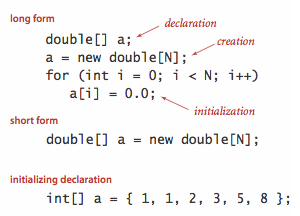

Java - Syntax für Deklaration eines double-Arrays und Zugriff über den Index

Betrachten Sie nochmals die Parameterliste der `main`-Funktion. Was für ein Datentyp wird übergeben? Wozu kann der Parameter `String[] args` genutzt werden?

Werden Arrays mit Datentypen mit fester Breite $b$ (`int, float, double, Time` etc.) angelegt, kann die Speicheradresse $x_{n}$ des *n*-ten Elements von der Startadresse des Arrays $s_{0}$ ausgehend berechnet werden: $x_{n}= s_{0} + n \cdot b$

In der C/C++ Programmierung spricht man von Speicher-Arithmetik.

### 5.3.2 Praktische Anwendung von Arrays

Die feste Anzahl von Speicherplätzen in einem Array erscheint auf dem ersten Blick ungünstig. Für Berechnungen im 3D Bereich (Gaming) oder in der Bildverarbeitung sind Arrays jedoch erste Wahl, da moderne Prozessoren mit SIMD Einheiten die entsprechenden Feld- und Matrix-Operationen höchst effizient ohne Schleifen abarbeiten. Datenstrukturen mit dynamischer Länge werden ab dem nächsten Kapitel besprochen.

### 5.3.3 Kopieren vs. Aliasing

Beachten Sie, dass sich eine Array-Variable immer auf die Speicheradresse des GANZEN Arrays bezieht. Es handelt sich dabei um eine sogenannte **Referenzvariable**. Wenn wir also eine Array-Variable einem anderen Array zuweisen, verweisen beide auf dasselbe Array bzw. Speicheradresse:

```
int[] a = new int[10];
a[i] = 1234;
int[] b = a;

//…

b[i] = 5678; //a[i] ist jetzt 5678!!
```

Eine solche Zuweisung wird **Aliasing** genannt. Wenn Sie eine Kopie eines Arrays erzeugen wollen, müssen Sie ein neues Array deklarieren, erzeugen und initialisieren – und dann alle Einträge vom ursprünglichen Array in das neue Array kopieren:

```
int N = a.length;
double[] b = new double[N];

for (int i = 0; i > N; i++){
	b[i] = a[i];
}
```

### 5.3.4 Array Boundaries

Java führt eine automatische Bereichsprüfung durch. Wenn Sie in einem Array mit 5 Elementen versuchen, mit dem Index Nr. 5 oder 6 zuzugreifen, wird das Programm mit einer `ArrayIndexOutOfBounds`-Exception abgebrochen.

### 5.3.5 Benutzer-Eingabe über Konsole oder GUI

Die Wahl der Benutzer-Eingabe (und Ausgabe) werden wir nicht festlegen. Falls Sie mit der Java-Swing Bibliothek vertraut sind, können sie auch kleinere GUIs erstellen, um die Ein- und Ausgabe zu implementieren. Andernfalls verwenden Sie die Ein-und Ausgabe der Konsole.

Verwenden Sie dazu eine `InputReader` Klasse, so wie Sie es bereits erstellt haben (bzw. fragen Sie die Lehrperson).

Wir werden in den folgenden Aufgaben mit primitiven Arrays arbeiten (z.B. für int oder double Daten). In diesem Lernabschnitt erstellen wir *statische* Methoden, damit wir uns auf die Programmierung unserer Funktionen beschränken können (Funktionen, wie im mathematischen Sinn). Später werden wir Klassen-eigene Funktionen implementieren.

**Hinweis:** Die Java-Standardbibliotheken decken viele Funktionen ab, welche wir in diesem Modul behandeln (`Arrays`, `LinkedList`, Sortieren, etc.). Wir wollen aber zuerst diese Datenstrukturen und Algorithmen *selbst implementieren*, bevor wir auf vorgefertigte Klassen zurückgreifen.

## 5.4 Übung: Elementare Array - Funktionalität

**Lernziel:**

- deklarieren und instanziieren Arrays
- beherrschen elementweisen Zugriff mit Indexen
- iterieren über alle Elemente eines Arrays
- erstellen elementare Array-Funktionen

**Zeit:** 45 Minuten

Erstellen Sie in Ihren `M411` Projekt eine neue Klasse `Skript1c_ArrayOps`. In dieser Klasse implementieren und testen Sie die folgenden statischen Funktionen. Beachten Sie die Schnittstellenbeschreibungen - Ein- und Ausgaben sollen nur in der `main`-Methode vorkommen. Zu jeder Teilaufgabe erstellen Sie sinnvolle Testfälle in der `main`-Methode.

### 5.4.1 Minimum und Maximum in einem Array suchen

Erstellen Sie je eine Funktion `getMinimum` und `getMaximum`. Die Funktionen sollen einen `int` Array als Parameter übernehmen und jeweils das Minimum bzw. Maximum bestimmen und zurückliefern. Verwenden Sie zum Testen in der `main`-Methode Arrays mit zehn Elementen mit fix-definierten oder zufällig gewählten Werten.

### 5.4.2 Arrays addieren

In der Vektoralgebra (die mathematische Grundlage für 3D - Games) müssen oft Arrays miteinander verrechnet werden. Für die Addition zweier Felder `a` und `b` in das Ergebnisfeld `c` wird elementweise das erste Element von `a` mit dem ersten Element von `b` addiert und im ersten Element von `c` gespeichert.

Dies funktioniert nur, wenn die Arrays die gleiche Länge haben. Erstellen Sie eine statische Funktion `addArray`. `addArray` erhält zwei `int`-Arrays als Parameter und gibt einen `int`-Array als Summe der Eingabe-Arrays zurück. Vor der Addition soll die Funktion prüfen, ob die Eingabefelder gleich lang sind.

### 5.4.3 Elemente nachrutschen

Erstellen Sie ein Funktion `prepend` mit einen Array und einen `int`-Wert in der Parameterliste. In der Funktion soll jeweils das neue Element an der ersten Stelle im Array eingefügt werden und die bereits vorhandenen Elemente hinten angefügt werden. Nach jeder Einfüge-Operation sollen alle Elemente des Arrays zurückgegeben werden.

### 5.4.4 Zusatz: Performance testen mit Zeitmessung

In dieser Aufgabe vergleichen Sie die Performance einer *selbstgebastelten* schleifenbasierten Kopierfunktion für Arrays mit der Performance der Java-Kopierfunktion `System.arrayCopy`. Mit `long t0 = System.currentTimeMillis();` können Sie die aktuelle Systemzeit in Millisekunden aufnehmen. Kopieren sie den eingelesenen Array 1000 mal mit einer for-Schleife in neuen Array kopieren und messen Sie die dazu benötigte Zeit. Vergleichen Sie den Zeitaufwand, wenn Sie das gleiche 1000 mal mit System.arrayCopy(...) kopieren.

[output not shown]

### 5.4.5 Zusatz: Terminal-App

Viele Systembefehle funktionieren nur auf der Konsole bzw. im Terminal. Oft bringen solche Programme eine Unzahl von verschiedenen Parametern mit (z.B. `dir *.txt`). Sie erstellen nun selbst ein solches Konsolenprogramm zum Bestimmen des Maximums und Minimums von Zahlenreihen in einer beliebigen Datei (eine Zeile enthält eine Zahl). Der Dateiname soll dabei als Parameter übergeben werden.

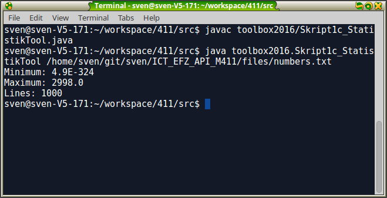

Java-Programm compilieren und mit Paramtern aufrufen

   **Lösungsvorschlag:**

   `Skript1c_StatistikTool.java`

## 5.5 Wiederholungsfragen

- Auf welche Arten können Array-Variablen angelegt werden?
- Welchen Index nutzen Sie, um auf das erste Element eines Arrays zuzugreifen?
- Wie bestimmen Sie die Anzahl der Elemente einer Array-Variable?
- Ihr Programm liefert eine `IndexOutOfBounds` Exception. Was ist passiert?
- Was versteht man unter Aliasing?

Zurück zum Inhaltsverzeichnis

# 6 Elementare Algorithmen und Laufzeit-Analysen

**Lernziele:**

- Sie kennen grundlegende Sortier-Algorithmen
- Sie visualisieren Algorithmen mit Struktogrammen oder PAP
- Sie kennen die Grundelemente von Algorithmen und deren Umsetzung in einer Programmiersprache.
- Sie implementieren einen Sortier-Algorithmus
- Sie kennen Laufzeit-Komplexitätsklassen von Algorithmen
- Sie schätzen die Laufzeit-Komplexität eines Algorithmus ab.

## 6.1 Der Bubble-Sort Algorithmus

Das Sortieren gehört zu den Standard-Abläufen in der Informatik und reicht von simplen Datensätzen zu grossen Datenvolumen. Es gibt sehr viele Sortier-Algorithmen. Den Klassiker *BubbleSort* werden wir hier näher betrachten:

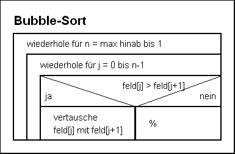

Quelle: [*http://www.tinohempel.de/info/info/ti/bubblesort.htm*](http://www.tinohempel.de/info/info/ti/bubblesort.htm)

In jedem Durchgang wird das Feld (bzw. Array) von links nach rechts durchlaufen. Dabei wird in jedem Schritt das aktuelle Element `feld[j]` mit dem rechten Nachbarn `feld[j+1]` verglichen. Bei *aufsteigender* Sortierung werden die beiden Werte getauscht, wenn `feld[j] > feld[j+1]`. Am Ende des ersten Durchganges steht garantiert das grösste Element am Ende der Liste, am Ende des zweiten Durchgangs das zweitgrösste an vorletzter Stelle usw.

Die Durchgänge werden solange wiederholt, bis die Eingabeliste vollständig sortiert ist. Dabei muss das letzte Element des vorherigen Durchlaufs nicht mehr betrachtet werden, da die restliche zu sortierende Eingabe keine größeren bzw. kleineren Elemente mehr enthält. Die Elemente bewegen sich also wie Blasen (engl. *Bubbles*) in einem Wasserglass nach oben (bzw. hinten), bis alle Blasen ihren Platz gefunden haben.

### 6.1.1 Bubble-Sort manuell durchspielen

Bevor wir den Algorithmus in Code umsetzen, werden wir diesen Algorithmus manuell durchspielen. Dazu brauchen Sie Papierschnipsel mit den unten stehenden Zahlen:

| 51 | 13 | 9 | 44 | 18 | 93 | 25 |
| --- | --- | --- | --- | --- | --- | --- |

Schreiben Sie diese Zahlen auf Notizpapier auf und zerschneiden Sie es. Dann ordnen Sie die Zahlenschnipsel wie oben angegeben an. Sortieren Sie nun die Schnipsel mit dem Bubble-Sort-Algorithmus und schreiben Sie die Ergebnisse aller Durchgänge auf. Wie viele Tauschvorgänge und Durchgänge werden benötigt?

Wie Sie vermutlich gemerkt haben, genügen $n$ Durchgänge. Mit jedem Durchgang landet mindestens eine der Zahlen an seinem definitiven Platz. Tatsächlich genügen sogar $n-1$ Durchgänge, weil die letzte Zahl keinen Nachbar mehr hat, mit dem sie vertauscht werden könnte.

## 6.2 Laufzeitanalyse

### 6.2.1 Anzahl Vergleichsoperationen

In einer Liste mit $n$ Zahlen existieren $n-1$ Paare von benachbarten Zahlen, die bei einem Durchgang verglichen werden müssen. Und wir haben höchstens $n$ Durchgänge. Somit sind maximal $n \cdot (n-1)$ Vergleichsoperationen nötig. Ausmultipliziert ergibt das $n^2-n$ Vergleichsoperationen. Da $n^2$ schneller wächst als $n$ können wir sagen, dass es ungefähr $n^2$ Vergleichsoperationen für eine Liste mit $n$ Elementen gibt. Man spricht hier von **quadratischer Komplexität**.

### 6.2.2 Aufwand im besten und im schlechtesten Fall

Wenn die Liste bereits sortiert ist, vergleicht der Algorithmus alle $n-1$ benachbarten Zahlenpaare einmal und stellt fest, dass es nichts zu tun gibt. Damit ist er fertig und es werden keine Zahlen vertauscht. Das ist der beste und schnellste Fall und benötigt $n-1$ Vergleiche und 0 Vertauschungen. Hier ist die Laufzeitkomplexität *linear*.

Im schlechtesten Fall ist die Liste genau andersherum sortiert, wie gewünscht. Dann müssen genau $n \cdot (n-1)$ Tauschoperationen und Vergleiche durchgeführt werden. Da der Aufwand einer Tauschoperation $3$ beträgt, erhalten wir folgende Komplexität: $3 \cdot n \cdot (n-1) = 3n^2 - 3n$. Konstanten können bei der Schätzung der Laufzeitanalyse weggelassen werden. Betrachtet wird immer nur der Summand mit dem grössten Exponenten. Also ist die Laufzeitkomplexitätsklasse im schlechtesten Fall ebenfalls *quadratisch*.

### 6.2.3 Übung: BubbleSort implementieren und Laufzeit analysieren

**Lernziele**

- üben systematische Vorgehensweise für Problemanalyse.
- erstellen Algorithmen in einer Programmiersprache.
- kennt Möglichkeiten zur Analyse von Zeit- und Speicherkomplexität von Algorithmen und Datenstrukturen

**Zeit:** 60 Minuten

1. Implementieren Sie den Bubble-Sort als statische Funktion in eine neuen Klasse `MyBubbleSort`. Verwenden Sie ein eigenes kurzes int-Array und geben Sie dieses vor und nach dem Sortieren in der `main`-Funktion aus. Ist das Ergebnis korrekt?
2. Wie viele Durchläufe gibt es, bis die Liste korrekt sortiert ist? Diese Frage können Sie nach unserem manuellen Beispiel einfach beantworten.
3. Erweitern Sie Ihre Sortier-Funktion, um die Durchläufe und Tauschoperationen zu zählen. Messen Sie zusätzlich die Dauer, wie lange der Bubble-Sort hat. Verwenden Sie dabei die `System`-Klasse mit der statischen Methode `currentTimeMillis()`. Testen Sie dann die in der Tabelle angegebenen Szenarien und komplettieren Sie die Tabelle für Ihr Moduljournal:

| **Elemente** | **Art der Werte** | **n Durchläufe** | **n Tauschoperationen** | **Rechenzeit** |
| --- | --- | --- | --- | --- |
| 1000 | aufsteigende Reihenfolge |  |  |  |
| 1000 | zufällige Werte |  |  |  |
| 1000 | absteigende Reihenfolge |  |  |  |
| 2000 | aufsteigende Reihenfolge |  |  |  |
| 2000 | zufällige Werte |  |  |  |
| 2000 | absteigende Reihenfolge |  |  |  |
| 4000 | aufsteigende Reihenfolge |  |  |  |
| 4000 | zufällige Werte |  |  |  |
| 4000 | absteigende Reihenfolge |  |  |  |

**Lösungsvorschlag:**

`Skript1c_BSortPerformance.java`

### 6.2.4 Komplexitätsklassen von Algorithmen

Die Berechenbarkeit eines Algorithmus ist ein sehr wichtiges Kriterium für dessen Eignung in der Programmierung. Stellen Sie sich vor, Sie haben einen dreifach verschachtelten Algorithmus zur Problemlösung in einer kurzen Datenstruktur gefunden. Was nützt dieser Algorithmus, wenn er das gleiche Problem mit einer sehr langen Datenstruktur erst in mehreren hundert Jahren lösen kann?

Vereinfacht kann die Rechenzeit eines Algorithmus wie folgt berechnet werden:

Man multipliziert man die Anzahl der Rechenschritte der inneren Schleife mit dem Rechenaufwand des Schleifenkopfes, und multipliziert diesen Wert mit dem Rechenaufwand der umschliessenden Schleife.

Was für die Komplexität der Rechenzeit zutrifft, gilt auch für die Speicherkomplexität. Je mehr Variablen in den inneren Schleifen zwischengespeichert werden, desto mehr Arbeitsspeicher wird der Algorithmus zur Laufzeit benötigen.

Die folgende Tabelle illustriert die wichtigsten Komplexitätsklassen von Algorithmen.

| **f(n)** |  | **f(10)** | **f(100)** | **f(1000)** | **f(10000)** |
| --- | --- | --- | --- | --- | --- |
| 1 | konstant | 1 | 1 | 1 | 1 |
| log<sub>2</sub>(n) | logarithmisch | 3 | 7 | 10 | 13 |
| n | linear | 10 | 100 | 1000 | 10<sup>4</sup> |
| n * log<sub>2</sub>(n) |  | 30 | 700 | 10<sup>4</sup> | 13 * 10<sup>4</sup> |
| n<sup>2</sup> | quadratisch | 100 | 10<sup>4</sup> | 10<sup>6</sup> | 10<sup>8</sup> |
| n<sup>3</sup> | kubisch | 1000 | 10<sup>6</sup> | 10<sup>9</sup> | 10<sup>12</sup> |
| 2<sup>n</sup> | exponentiell | 1000 | 10<sup>30</sup> | 10<sup>300</sup> | 10<sup>3000</sup> |

Komplexitätsklassen und Beispiele, nach M.Wirsing; LMU München 2008

### 6.2.5 Übung: Laufzeitkomplexität von Algorithmen bestimmen

**Lernziele**

**Art:** Partnerarbeit

**Zeit:** 30 Minuten

**Hilfsmittel:** Skript, kein PC

**Aufgabe:** Bestimmen Sie die Laufzeit und Komplexitätsklasse der folgenden drei Algorithmen. Schreiben Sie den Rechenweg vollständig unter oder neben die Funktionen.

1. ```
   public int[][] calcCrossProduct(int[] vector){
   int[][] result = new int[vector.length][vector.length];
   for (int i=0; i < vector.length;i++)
   	for (int j = 0; j<vector.length;j++)
   		result[i][j]=vector[i]*vector[j];

   return result;
   }
   ```

2. ```
   public float getMean(int[] arr){
   int sum = 0;
   for (int i : arr)
   	sum+=i;

   return sum/arr.length;
   }
   ```

3. ```
   // arr must be sorted before
   public int findBinary(int [] arr, int search){
   int index = (int) Math.floor(arr.length/2);
   int inc = index;

   while (arr[index]!=search && inc>0){
   	inc = (int)Math.floor(inc / 2);
   	if (arr[index]>search)
   		index -= inc;
   	else index += inc;
   }
   if (arr[index] != search)
   	return -1;

   return index;
   }
   ```

## 6.3 Übung: Weiterführende Aufgaben mit Bubble-Sort

**Lernziele:**

- anwenden und ändern Sortierfunktionen
- anwenden Sortieralgorithmen für komplexe benutzerdefinierte Klassen
- anwenden objektorientierte Programmierparadigmen

**Zeit:** 60 Minuten

Der Bubble-Sort ist für numerische wie auch alphanumerische Sortieraufgaben geeignet. Dies funktioniert, weil sich die Problematik in den beiden Fällen nicht unterscheidet:

`5 > 2` vs. `'D' > 'B'`

Vergleichen Sie dazu die ASCII-Tabelle [siehe Wikipedia](https://de.wikipedia.org/wiki/American_Standard_Code_for_Information_Interchange#ASCII-Tabelle).

Sollen nun ganze Worte alphabetisch geordnet werden, müssen ggf. weitere aufeinander folgende Buchstaben miteinander verglichen werden. Z.B. liegt "Muheim" vor "Mutzer".

### 6.3.1 Strings sortieren

Erstellen Sie eine Klasse `Skript1c_StringBSort`. Darin lesen Sie ein File mit 10 Strings ein und sortieren Sie diese in alphabetischer Reihenfolge. Danach geben Sie die 10 sortierten Strings in der Konsole aus.

**Lösungsvorschlag:**

`Skript1c_StringSort.java`

### 6.3.2 Array einer benutzerdefinierten Klasse sortieren

In dieser Aufgabe lernen Sie, Arrays von Benutzerklassen zu sortieren. Ab hier arbeiten Sie wieder richtig objektorientiert, d.h. Daten werden in Klassenvariablen gespeichert und Funktionalität ist in Klassenmethoden implementiert. Die `main`-Funktion dient nur als Testrahmen.

1. Erstellen Sie eine Klasse `Skript1c_PersonBsort`. Erstellen Sie nun eine Klasse `Person` mit den Attributen `Vorname`, `Nachname` und `Geburtsjahr`. Der Konstruktor der Klasse `Person` übergibt alle diese Parameter.
2. Erstellen Sie eine Klassenvariable `Person[] personenArray`. Diese soll in einer Klassenfunktion `readPersonFile` mit den Personen aus das Datei `daten.csv` gefüllt werden (siehe `Skript1_SimpleCsvReader`). Beachten Sie, dass die Anzahl der Personen variabel ist und am Ende der Funktion der Array `personenArray` nur gültige Werte enthält.
3. Erstellen Sie eine Sortierfunktion, die Ihren Array nach dem Nachnamen *absteigend* sortiert. Geben Sie `personen` vor und nach dem Sortieren aus.

**Lösungsvorschlag:**

`Skript1c_Personen.java`

## 6.4 Übungen für Fortgeschrittene: Quick-Sort und Insert-Sort

### 6.4.1 Optional: Quick-Sort

Der Quick-Sort ist ziemlich beliebt, weil er sich leicht implementieren lässt und mit verschiedenen Eingabedaten zurechtkommt. In typischen Anwendungen ist Quick-Sort erheblich schneller ist als jedes andere Sortierverfahren.

- Informieren Sie sich über die Funktionsweise des Quick-Sort Algorithmus.
- Skizzieren Sie den Ablauf in einem Struktogramm oder PAP.
- Implementieren Sie den Quick-Sort.
- Welche neue, bisher nicht benützte Eigenschaft benötigt der Quick-Sort?

### 6.4.2 Optional: Insert-Sort

Ein weiterer Sortier-Algorithmus ist der Insert-Sort. Untersuchen Sie das Prinzip des Insert-Sort. Was ist der Unterschied zum Quick-Sort?

Implementieren Sie den Insert-Sort und zeigen Sie die Unterschiede zum Quick-Sort.

Vergleichen Sie diese Sort-Algorithmen mit dem Bubble-Sort, indem Sie auch die Dauer messen.

Zeigen Sie Ihre Lösungen zu Quick-Sort und Insert-Sort der Lehrperson.

**Lösungsvorschlag:**

[output not shown]

## 6.5 Wiederholungsfragen

- Wie funktioniert der BubbleSort-Algorithmus?
- Welche Laufzeit-Komplexitätsklassen gibt es? Sortieren Sie diese nach Performance absteigend.
- Wie bestimmen Sie die Laufzeit einer Methode?

Zurück zum Inhaltsverzeichnis

# 7 Dynamische Datenstrukturen: Verkettete Liste

## 7.1 Lernziele

- kennen den Unterschied zwischen Wertevariablen und Referenzvariablen / Zeigervariablen.
- kennen Sprachmittel einer Programmiersprache für das Deklarieren und das Arbeiten mit Werte- und Referenzvariablen.
- beschreiben das Konzept und den Nutzen von verketteten Datenstrukturen.
- zeichen eine Notation für die Darstellung von verketteten Datenstrukturen.
- implementieren eine einfach verkettete Liste
- sortieren einfach verkettete Listen

## 7.2 Eine elementare Datenstruktur: Verkettete Liste

Objekt-Arrays sind denkbar ungeeignet, wenn wir dynamische Datenmengen (veränderliche Anzahl von Objekten) verwalten wüssen.

Als schlaue Alternative kommt eine weitere elementare Datenstruktur zur Anwendung, welche ihre Grösse schnell und unkompliziert verändern kann (was wir bei einem Array nicht können):

Die Verkettete Liste (Abk. **VK**, engl. *LinkedList*) kann mit dynamischen Datenmengen umgehen. Ein weiterer Vorteil ist, dass sie eine höhere Flexibilität ermöglicht, indem die Elemente in effizienter Weise umgeordnet werden können. Dafür ist ein schneller Zugriff auf ein Element über den Positionsindex nicht möglich. Das erklärt sich aus der internen Struktur der verketteten Liste:

Jedes Element der einfach verketteten Liste enthält neben dem eigentlichen Wert die Speicheradresse des nächsten Listenelements. Die Speicheradresse nennt man in der C / C++ Welt auch Zeiger. Der "Zeiger" ist damit die Verknüpfung oder das Bindeglied innerhalb der Liste, durch den jedes Element das nächste Element kennt.

Ein Element ist somit ein Knoten ("Node"), welches durch Verkettung bzw. Verknüpfung auf den nächsten Knoten verweist ("next").

Der Zugriff auf eine VK erfolgt grundsätzlich vom ersten Element der Liste (*head*). Daraus folgt, dass eine VK immer von Anfang an durchschritten werden muss, bis das gewünschte Element an einer bestimmten Position geliefert werden kann.

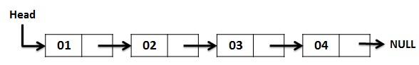

Notation einfach verkettete Liste, Quelle: CrunchifyCode

Neben der einfach verketteten Liste gibt es auch doppelt verkettete Listen. Die Nodes der doppelt verketteten Liste enthalten neben der Zeigeradresse des Nachfolgeelements auch eine Zeigeradresse auf das Vorgängerelement.

### 7.2.1 Implementierung

In einer objektorientierten Sprache ist die Implementierung von verketteten Listen nicht sehr schwierig.

**Die Node-Klasse**

Wir beginnen mit dem Node-Object als innere Klasse, welche die Knotenabstraktion definiert:

```
private class Node{
	Item item;
	Node next;
}
```

Ein `Node`-Objekt besitzt zwei Instanzvariablen: eine vom abstrakten Typ `Item` (ein parametrisierter Typ, den Sie selber bestimmen können) und eine weitere Instanzvariable vom Typ `Node` selbst. Eine Datenstruktur, die sich selbst als Variable enthält, nennt man rekursive Datenstruktur.

Wir definieren `Node` direkt innerhalb der Klasse, in der wir sie verwenden wollen, und zwar als *private*, da Clients keinen Zugriff darauf erhalten sollen.

**Beispiel für die innere Klasse:**

```
private class Node{
	//these are private
	private Object item;
	private Node next;

	//constructor
	public Node (Object value){
		next = null;
		item = value;
	}

	//another constructor
	public Node(Object value, Node nextValue){
		next = nextValue;
		item = value;
	}
}
```

Die Instanzvariable `item` wird in unserem Beispiel als `Object` Datentyp deklariert und kann damit alle von Object abgeleiteten Datentypen aufnehmen (also `int, double, String`,...).

Der Basis-Konstruktor setzt das nächste Element auf *null*, weil es nur das aktuelle Element initialisiert. Die Klasse `Node` hat natürlich auch `set`- und `get`-Methoden, um auf die Daten zugreifen zu können. `Node` benötigt keine weiteren Methoden, da es sich um eine reine Datenstruktur handelt.

## 7.3 Die MyLinkedList - Klasse

Ausserhalb der inneren Klasse implementieren wir die eigentliche Klasse `MyLinkedList`, in welcher die Node-Objekte verkettet werden:

```
public class MyLinkedList {
	private Node head; //reference to the head node
	private int listCount; //counter used for looping

	//constructor
	public MyLinkedList(){
		//when initialised it's an empty list, so the reference to the
		//head node is set to a new node with no data:
		head = new Node(null);
		listCount = 0;
	}
…
}
```

Ganz wichtig ist, dass im Konstruktor eine Liste mit einem Element erstellt wird. Wir verwenden dabei das vorderste Element (`head`). Das vorderste Element hat noch keinen Verweis auf ein Nächstes, deshalb setzen wir den Knoten `next` auf null.

### 7.3.1 Elemente hinzufügen:

Prinzip: ein neues Element wird ans Ende der Liste gestellt. Also muss jeweils von `head` ausgehend zunächst das Ende der Liste gesucht werden.

Innerhalb der MyLinkedListKlasse:

```
public void append(Object value){
	Node newElement = new Node(value);
	Node current = this.head; //set current to head (start) of the list
	//make sure to add at the end of the list, loop through the elements:
	while (current.getNext() != null){
		current = current.getNext();
	}
	//add the new element to the end of the list:
	current.setNext(newElement);

	//increment list counter:
	listCount++;
}
```

Wichtig sind die letzten 4 Zeilen. Das aktuelle Element `current` (dh. das letzte) zeigt neu auf ein weiteres Element. Das wird somit zum neuen letzten Element. Zudem muss der Listen-interne Zähler inkrementiert werden.

## 7.4 Übungen: Verkettete Liste

**Lernziele:**

- erstellen eigene verkettete Liste
- erstellen Grundfunktionen für Verkettete Liste

**Zeit:** 60 Minuten

**Art:** Sie können gern in Zweier-Teams arbeiten

### 7.4.1 Eigene verkettete Liste implementieren

Schreiben Sie eine Klasse `Skript2a_VK` für verkettete Listen mit der entsprechenden *inneren Klasse* `Node` für die Datenstruktur. Ihre Liste soll zunächst beliebige Daten abspeichern können.

1. Implementieren Sie die Methode `append`. Testen Sie, ob Ihre Liste funktioniert, indem der Benutzer Zahlen oder Wörter eingeben kann.
2. Implementieren Sie eine Methode `showNodeAdressAndValue`, welche alle vorher eingegebenen Werte gefolgt von der tatsächlichen Speicheradresse der jeweiligen Node ausgibt. Die Speicheradresse eines Objekts kann mittels `(Object)x.toString()` ausgegeben werden. Testen Sie die Methode, indem Sie eine Liste automatisch mit 10 Zufallszahlen füllen. Danach beobachten Sie die Werte der aufeinanderfolgenden Speicheraddressen.
3. Erstellen Sie eine weitere Methode `showElementsReverse`, welche diese mittels einer Schleife wieder ausgibt. Die Wörter sollten in umgekehrter Reihenfolge erscheinen.

   Eingabe: *Hello, Arnold, how are you doing?*

   Ausgabe: *doing? you are how Arnold, Hello,*
4. Elemente entfernen

   Erweitern Sie Ihre Klasse um eine Funktion `public Object pop()`, die jeweils das letzte Element entfernt und den Wert dieses Elements zurück gibt.
5. Erstellen Sie eine Funktion `prepend`, welche Elemente jeweils am Anfang der Liste abfüllt und dabei alle bereits vorhandenen Elemente entsprechend nach hinten rutscht. Das zuletzt eingegebene Element wird somit das erste Element in der Liste. Verwenden Sie dieses Mal Ihre Verkettete Liste. Welche Struktur ist einfacher? Der simple Array oder die Verkettete Liste?
6. Elemente an einer bestimmten Position einfügen / entfernen

   Jetzt erweitern wir die Liste, damit Elemente an einer bestimmten Position eingefügt oder gelöscht werden können. Erstellen Sie eine verkettete Liste, welche aus String-Elementen besteht. Wir wollen folgenden Satz anpassen:

   *To be or not to be, that is the question.*

   *To be or not to be, my dear Hamlet, that is the question.*

**Lösungsvorschlag:**

`Skript2a_VK.java`

## 7.5 Verkettete Liste vs. Array

Ein grosser Vorteil der verketteten Liste ist die dynamische Grösse. Die Anzahl Elemente müssen nicht fix definiert sein. Anderseits ist der Zugriff in einer verketteten Liste viel mühsamer als in einem Array. In einem Array können wir jederzeit via Index direkt auf ein Element zugreifen. In der verketteten Liste müssen wir die Liste bis zum gewünschten Element durchschreiten.

## 7.6 Übung: Erweiterte Aufgaben zu verketteten Listen

**Lernziele:**

- erstellen eigene verkettete Liste
- anwenden Sortieralgorithmen für komplexe benutzerdefinierte Klassen
- anwenden objektorientierte Programmierparadigmen

**Zeit:** 60 Minuten

**Art:** Sie können gern in Zweier-Teams arbeiten

### 7.6.1 Verkettete Liste sortieren und Laufzeit messen

Kopieren Sie Ihren Quellcode der verketteten Liste in eine neue Java-Klasse `Skript2a_VK2`. Ändern Sie den Datentyp des *item*-Elements der `Node` Klasse von `Object` auf `Double`. Ändern Sie ebenso alle entsprechenden Konstruktoren und Methoden der `Node` und `Skript2a_VK2` Klasse. Schreiben Sie eine Klassenmethode für `Skript2a_VK2`, welche die Listenelemente sortiert. Testen Sie Ihre Sortierfunktion zunächst mit einigen wenigen Elementen auf Richtigkeit. Danach füllen Sie drei Listen mit 100, 1000 und 10000 Zufallszahlen und lassen sich die Laufzeit der Sortierung ausgeben.

**Lösungsvorschlag:**

`Skript2a_VK2.java`

### 7.6.2 Verkette Liste für `Person`-Klasse

Kopieren Sie Ihren Quellcode der verketteten Liste in eine neue Java-Klasse `Skript2a_VK_Person`. Ändern Sie den Datentyp des *item*-Elements der `Node` Klasse von `Object` auf `Person`. Das funktioniert prima, wenn Sie die Klasse `Person` bereits in den vorigen Übungen im gleichen *package* erstellt haben. Ändern Sie nun alle entsprechenden Konstruktoren und Methoden der `Node` und `Skript2a_VK_Person` Klasse. Schreiben Sie eine Klassenmethode für `Skript2a_VK_Person`, welche die Listenelemente nach Nachname **absteigend** sortiert. Testen Sie Ihre Sortierfunktion auf Richtigkeit.

**Lösungsvorschlag:**

`Skript2a_VK_Person.java`

## 7.7 Wiederholungsfragen

- Welche Daten können in verketteten Listen gespeichert werden?
- Welche Vor- und Nachteile ergeben sich beim Einsatz von verketteten Listen bzw. Arrays?
- Beschreiben Sie Ihrem Nachbarn den Aufbau einer verketteten Liste.
- Was ist zu beachten, wenn Sie ein Element aus einer verketteten Liste entfernen?
- Vergleichen Sie die Laufzeit des BubbleSort-Algorithmus für Arrays und verkettete Listen.

Zurück zum Inhaltsverzeichnis

# 8 Dynamische Datenstrukturen II: Stacks und Queues

## 8.1 Lernziele

- beschreiben Eigenschaften der Datenstruktur Stack (Stapel) und Queue
- einsetzen Datenstrukturen Stack und Queue
- implementieren und anwenden Interface `Iterator`

## 8.2 Die verkettete Liste als Stapel-Speicher

Mit Hilfe der *verketteten Liste*, können wir eine weitere häufig benützte Datenstruktur mit speziellen Eigenschaften umsetzen: den Stapel, bzw. Stack.

Der Stack arbeitet nach dem LIFO-Prinzip ("last in – first out"). Als Analogie können Sie sich den Stack wie einen Stapel Teller in der Mensa vorstellen:

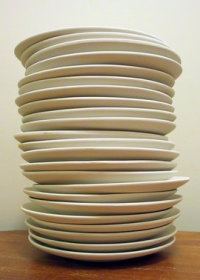

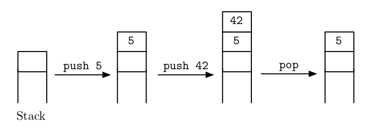

Die Grundoperationen für einen Stack sind:

*push* -> ein Element zuoberst hinzufügen

*pop* -> das Element zuoberst entfernen

Praktische Anwendung finden Stack-Datenstrukturen beispielsweise in *UNDO* Funktionen von Bild- und Dokumentbearbeitungsprogrammen. Weniger sichtbar, aber für die Arbeit am PC wichtig ist die Stack-Architektur des Speichers, den ein Programm während der Laufzeit benutzt. Jeder neue Methodenaufruf X bekommt einen Speicherbereich *oberhalb* der aufrufenden Funktion A, der nach Beendigung der Funktion X wieder freigegeben wird. Durch diese Architektur wird beispielsweise die Lebensdauer und vor allem die Sichtbarkeit der lokalen Variablen beeinflusst.

Die innere Datenstruktur der verketteten Liste (`class Node`) eignet sich sehr gut, um einen Stack umzusetzen. Wir schreiben somit eine `Stack`-Klasse, welche die Datenstruktur der verketteten Liste wieder verwendet:

```
public class MyStack {
	//reference to the first element in stack (=last added element)
	private Node first;
	//counter
	private int listCount;

	//constructor
	public MyStack(){
		listCount= 0;
	}

	//TODO:add push and pop methods here
}
```

Wir fügen ein Element zuvorderst in die Kette, mit einer `push` Methode:

```
//Adds element to the top of the list
public void push(Object value){
	//the new element is the last in the list:
	Node current = first;
	first = new Node(value);
	first.setNext(current);
	listCount++;
}
```

Die Funktion `pop` entnimmt das oberste Element der Liste und gibt es zurück:

```
//Removes top element from stack
public Object pop(){
	Object value = first.value;
	first = first.next; //now next element is the first
	listCount--;
	return value;
}
```

Ein Aufruf in der main-Methode sieht somit wie folgt aus:

```
MyStack list = new MyStack();
list.push("to");
list.push("be");
list.push("or");
list.push("not");
```

## 8.3 Übungen: Stack implementieren und für Kartenspiel nutzen

**Lernziele**

- erstellen und benutzen Stack-Datenstruktur in akademischer und praktischer Variante

**Zeit:** 30 + 45 + x Minuten

### 8.3.1 Stack Klasse erstellen

Implementieren Sie Ihre `Stack` Klasse mit den `push` und `pop` Methoden. Bei `push` wird ein Element zuoberst hinzugefügt. Bei `pop` wird das aktuelle Element entfernt. Sie können den Code Ihrer `Node`- Klasse der Verketten Liste für die interne Datenstruktur übernehmen.

Testen Sie die Funktionalität mit einem geeigneten Testrahmen.

### 8.3.2 `isEmpty()`-Methode implementieren

Fügen Sie eine `isEmpty()`-Methode hinzu. Diese überprüft, ob es Elemente im `Stack` hat. Die Methode gibt einen boolean zurück.

### 8.3.3 Stack ergänzen

Ergänzen Sie `Stack` um eine Methode `peek()`, welche das zuletzt auf dem Stapel gelegte Element zurück liefert ohne es zu entfernen.

### 8.3.4 Palindrome prüfen (25 Minuten)

Verwenden Sie den `Stack` um zu überprüfen, ob ein String ein Palindrom ist. Gültige Palindrome sind beispielsweise *OTTO*, *ANNA*, oder *RACECAR* - also Worte oder Sätze, die dasselbe von vorne und von hinten gelesen gleich sind. Mit einem `Stack` lässt sich das einfach überprüfen. Erweitern Sie den Code, so dass der Benutzer einen String eingeben kann.

Verwenden Sie für diese Lösung ihren eigenen `Stack`.

**Lösungsvorschlag:**

`Skript2b_ObjectStack.java`

### 8.3.5 Kartenstapel implementieren (45 Minuten)

*Einführung:* Sie wollen gern ein PC-Kartenspiel entwickeln. Dazu wird zunächst ein Kartenstapel benötigt. Die einzelnen Karten sollen als Objekte der Klasse `Card` mit den Attributen `String farbe`, `int wert` und `String anzeige` angelegt werden. Damit es ein echter Kartenstapel wird, speichern Sie alle Karten in einem Stack ab.

*Auftrag:* Erstellen Sie einen Stack von Patience- bzw. Solitär-Karten (52 Karten, 4 Farben {Karo, Herz, Pik, Kreuz} mit den Zahlen 2 bis 10, Bube, Dame, König, Ass). Zur späteren Spielimplementierung geben Sie den Zahlen-Karten die Werte 2 - 10 zu. Bube bekommt Wert 11, Dame den Wert 12, König = 13 und Ass = 14. Nutzen Sie sinnvolle Schleifenkonstrukte zum Generieren der Karten.

**Lösungsvorschlag:**

`Skript2b_CardStack.java`

*Zusatz:* 1. Mischen Sie die Karten in Ihrem Stack. 2. Entwerfen Sie eine grafische Oberfläche für ein Kartenspiel. Dazu leiten Sie Ihre `Card`-Klasse von `JPanel` ab und erstellen eine Klassenmethode `public void paint(Graphics g)`, in der die jeweilige Karte als JPanel gerendert wird. Den Stack können Sie beispielsweise auf einer JLayeredPane realisieren.

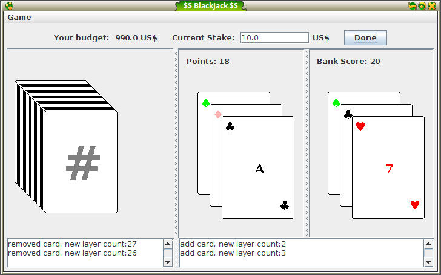

Beispiel Black Jack

## 8.4 Die Verkettete Liste als Warteschlange

Eine weitere wichtige Spezialform der Verketteten Liste ist die Warteschlange (engl. Queue). Wie an der Supermarkt-Kasse werden bei einer Queue neue Elemente hinten angehängt. Entfernt werden nur Elemente von vorne. Dabei spricht man vom FIFO (First-In First-Out), im Gegensatz zum LIFO bei der Stack-Datenstruktur.

Bedeutende praktische Anwendung für Queues sind beispielsweise Anzeigetafeln für Zugsabfahrten an Bahnhöfen oder Callcenter-Routingsysteme.

## 8.5 Verwendung von `Iterator` anstelle von `for`- oder `while`-Schleifen

Anstatt der üblichen (und fehleranfälligen) `for`-Schleife zum Durchlaufen aller Elemente des Stacks bzw. der Verketteten Liste sollen nun Iteratoren eingesetzt werden.

Iteratoren erlauben dem Benutzer, nacheinander auf jedes Element einer Datenmenge zuzugreifen, unabhängig wie die dahinter liegende Datenstruktur implementiert ist. Der Iterator kümmert sich dabei hinter den Kulissen um die Grenzen der Datenstruktur.

Eine Iteratorklasse wird in enger Koordination mit ihrer Containerklasse, also ihrer Menge, entworfen. Üblicherweise stellt die Containerklasse die Funktionen zur Verfügung, die zur Erstellung von Iteratoren benutzt werden.

Gewissermassen sind Iteratoren die Vorfahren der foreach-Schleife in Java, PHP & Co.

Zum Implementieren des Iterators innerhalb der Verketteten Liste bzw. Stack verwenden wir das Interface (Schnittstelle) `Iterable` und `Iterator`. Damit wird die Wiederverwendbarkeit sichergestellt und die Einarbeitungszeit für externe Programmierer reduziert. Zum Verwenden der Schnittstellen schreiben wir das **implements** Schlüsselwort und die beiden Schnittstellennamen in der Klassendeklaration hinter den Klassennamen.

```
public class MyStack implements Iterable<Object>, Iterator<Object>{

	//reference to the first element in stack (=last added element)
	private Node first;
	private Node currentIterPos; //contains current position of iterator

	//…
}
```

`Iterable<Object>` und `Iterator<Object>` sind sogenannte generische Schnittstellen. D.h sie können auf verschieden Datentypen innerhalb der implementierenden Datenstruktur angewandt werden. Für eine Liste mit Elementen der Klasse `Person` spezialisieren Sie die Schnittstelle entsprechend: `public class MyStack implements Iterable<Person>, Iterator<Person>`.

Für die Generischen Schnittstellen in unserer Datenstruktur benutzen wir also den gleichen Datentyp wie in der Node-Klasse enthalten. Zusätzlich benötigen wir eine neue `Stack`-Klassenvariable zur Verwaltung der aktuellen Listenpostion: `currentIterPos`. `currentIterPos` ist vom Datentyp `Node`.

Das Interface `Iterable` verlangt, dass wir die Methode `public Iterator<Object> iterator()` innerhalb der Klasse MyStack implementieren. Nichts einfacher als das:

```
public Iterator<Object> iterator(){

	this.currentIterPos = this.head; //set current position=top of stack
	return this;
}
```

Das Interface `Iterator` verlangt zwingend, dass folgende Methoden implementiert sind:

- `hasNext()` -> gibt true oder false zurück
- `next()` -> gibt das nächste Element zurück
- `remove()` -> entfernt ein Element

Die Methode `remove()` lassen wir leer, weil wir es vermeiden wollen, Elemente aus einer Liste zu entfernen, wenn wir gleichzeitig auch noch iterieren.

Uns interessiert vor allem `hasNext()` und `next()`. Für `hasNext()` prüfen wir, ob das aktuelle Element noch einen Nachfolger hat. Das sieht dann wie folgt aus:

```
@Override
public boolean hasNext() {
	return this.currentIterPos.next != null; // return false if null
}
```

## 8.6 Übung: Arbeiten mit Iteratoren

**Lernziele**

- implementieren und anwenden Iteratoren

**Zeit:** 25 Minuten

### 8.6.1 Methode `next()` implementieren

Sie implementieren die Schnittstellen `Iterable<Object>` und `Iterator<Object>` in Ihrer Stack-Klasse.

Wie muss die Methode `next()` aussehen, damit wir jeweils das nächste Element (und dessen Inhalt) bekommen? Ergänzen Sie den unten stehenden Code in Ihrem Programm:

```
@Override
public Object next() {

	//TODO: complete code here

	Object item = this.currentIterPost.value;
	return item;
}
```

Testen Sie diese Methoden, indem Sie eine while-Schleife für `hasNext()` implementieren.

**Lösungsvorschlag:**

`Skript2b_Iterator.java`

## 8.7 Wiederholungsfragen

- Was ist der Unterschied zwischen einer *Queue* und einer *Stack*-Datenstruktur?
- Wie können Sie Ihre Verkettete Liste optimieren, damit die `Queue`-Funktionen `push` und `pop` performant arbeiten?
- Was müssen Sie tun, wenn Sie in einer Klasse eine Schnittstelle implementieren?
- Wozu dient die `Iterator`-Schnittstelle?

Zurück zum Inhaltsverzeichnis

# 9 Dynamische Datenstrukturen III: Java Collections

## 9.1 Lernziele

- kennen den Aufbau der Java Collections
- erklären am Beispiel des Collection Interfaces die Bedeutung von Schnittstellen
- erklären die Bedeutung von generischen Klassen und Schnittstellen
- nutzen wichtige Datenstrukturen der Java Collection-Library
- anwenden Lambda-Funktionen für Suche und Sortieren innerhalb einer Collection

## 9.2 Datenstrukturen in Java: Die Collections-Bibliothek

Das Package `java.util` stellt häufig genutzte Datenstrukturen wie Listen, Stacks und Queues mit wichtigen Funktionen bereit. Durch den Einsatz dieser Klassen können sich Entwickler viel Zeit zum Erstellen und Testen solcher Datenstrukturen sparen und sich auf die eigentliche Problemlösung konzentrieren.

## 9.3 Die Schnittstellen Collection und List

Die Datenstrukturen aus `java.util` nutzen die gemeinsame Schnittstelle `Collection`. Diese Schnittstelle definiert allgemeine Methoden und Funktionen, die innerhalb der Klassen implementiert sind. Eine Schnittstelle selbst beinhaltet allerdings keinen Code. Schnittstelle heisst auf Englisch interface. Beide Begriffe werden hier synonym gebraucht.

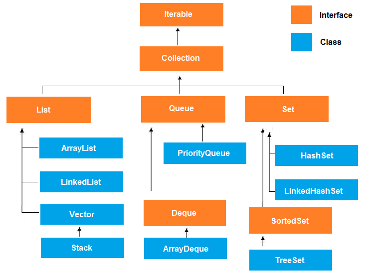

Quelle: http://www.beingjavaguys.com/2013/03/java-collection-framework.html

Bei der Benutzung einer Klasse, die diese Schnittstelle implementiert, wissen Entwickler, welche Funktionen vorhanden sind. Dies dient der schnelleren und stabileren Software-Entwicklung.

Beispiele für Methoden des `Collection`-Interfaces sind:

- `add(Object o)`
- `remove(Object o)`
- `iterator()`
- `size()`
- `stream()`
- `toArray()`

Das `List`-Interface definiert zusätzliche Methoden, um über Index-Adressen auf Listenelemente zuzugreifen:

- `remove(int pos)`
- `add(<T> object, int pos)`

Mit dem ebenfalls definierten `ListIterator` können die Datenstrukturen vorwärts *und* rückwärts durchschritten werden.

## 9.4 Implementierung der Schnittstellen in Klassen des `java.util` Pakets

Die bisher behandelten Datenstrukturen sind in Java auch in der Collections-Bibliothek enthalten:

| *verwendete Datenstruktur* | *In Collections-Bibliothek* |
| --- | --- |
| primitiver Array | `ArrayList*` oder `Arrays` |
| Verkettete Liste | `LinkedList*` |
| Eigener Stack / Stapel | `Stack**` |
| noch nicht behandelt | `Map` |

`*` beide Klassen implementieren das Interface `List`

`**` Wie in Abbildung 1 sichtbar, ist der `Stack` eine Erweiterung der `Vector` Klasse. Der `Vector` wiederum ist eine spezielle Form eines Arrays. Wie bei `ArrayList` ist ein `Vector` dynamisch erweiterbar, hat aber den Vorteil, dass es **synchronized** ist (d.h. er kann nicht gleichzeitig von mehreren Prozess geändert werden).

Die Verwendung des Interfaces `Collection` ermöglicht die Definition des *inneren* Datentyps schon bei der Instantiierung eines Collection-Objekts:

`List<String> myStrings = new ArrayList<String>();`

`Stack<Card> deck42 = new Stack<Card>();`

Solche Klassen und Schnittstellen werden in Java *generisch* bezeichnet. In C++ wird der Begriff Template-Klasse genutzt.

## 9.5 Anwendungsgebiete von `ArrayList`, `Vector` und `LinkedList`

Die Klassen `ArrayList`, `Vector` und `LinkedList` stellen dynamische Datenstrukturen dar. Die Anzahl der darin gespeicherten Elemente darf sich also zur Laufzeit des Programms ändern. Da alle diese Klassen das `List`-Interface implementieren, stehen (unter anderem) folgende Methoden zur Verfügung:

- `add(int index, Element e)`
- `remove(Element e)`
- `remove(int index)`
- `get(int index)`

Äusserlich betrachtet erfüllen diese Funktionen das Gleiche in allen drei Klassen. Laufzeit-technisch bestehen jedoch Unterschiede:

- `ArrayList` und `Vector` sind intern als Array implementiert. Zugriffe auf die einzelnen Elemente sind also sehr schnell und unabhängig von der Anzahl der enthaltenen Elemente. Jedoch sind Operationen wie das Hinzufügen oder Entfernen von Elementen rechenintensiv, da das gesamte Feld neu strukturiert werden muss. Der Vorteil bei der Benutzung der `Vector`-Klasse liegt insbesondere in der Absicherung für gleichzeitige Zugriffe bei paralleler Programmierung.
- Die Klasse `LinkedList` ist intern als verkettete Liste implementiert und unterstützt das Durchschreiten von vorne nach hinten. Die Zugriffszeit auf einzelne Elemente ist abhängig von der Position und steigt linear mit der Anzahl der Elemente. Das Gleiche trifft auf Einfüge- und Löschoperationen zu.

Die folgende Abbildung illustriert die Laufzeitabhängigkeiten:

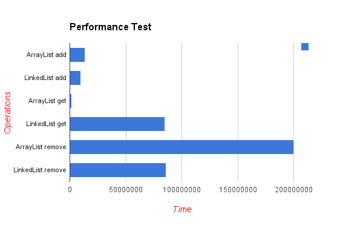

Laufzeitverhalten von LinkedList und ArrayList, Quelle: www.programcreek.com/2013/03/arraylist-vs-linkedlist-vs-vector/

**Zusammenfassung**: Setzen Sie `ArrayList` oder `Vector` ein, wenn Sie sehr schnelle Lesezugriffe benötigen und relativ wenige Einfüge- und Löschoperationen zu erwarten sind. Andernfalls ist die `LinkedList` ein guter Kandidat.

Weitere Informationen finden Sie hier: www.programcreek.com/2013/03/arraylist-vs-linkedlist-vs-vector/

## 9.6 Die `foreach`-Schleife mit Collections

Eine grundlegende Operation auf Collections ist die Verwendung von `foreach` zum Durchlaufen und Bearbeiten aller Elemente in einer Collection. Im Gegensatz zum klassischen `for` müssen Sie hier keine `int`-Schleifenvariable hochzählen und am Ende abbrechen. Das jeweilige Listenelement steht Ihnen direkt zur Verfügung (im Beispiel `String s`). Das führt zu sehr kompaktem Code, wie in diesem Beispiel für einen Stack:

```
Stack<String> collection = new Stack<String>();
…
for (String s: collection){
	System.out.println("Element = " + s);
}
```

Welche andere `for`-Schleife könnte man für die gleiche Operation verwenden? Notieren Sie diese andere `for`-Schleife (diese sollten sie jetzt ziemlich gut kennen)

Der `Iterator` selbst ist ein Interface. Sobald eine Klasse dieses Interface implementiert, hat es automatisch das Verhalten eines Iterators. Siehe dazu die JavaDoc-Hilfe unter `java.util.Iterator`.

## 9.7 Lambda-Funktionen

Wie haben vorher einige Sortierfunktionen selbst erstellt. `java.utils` stellt auch hier hocheffiziente fertige Funktionen zur Verfügung, welche die Programmierer nur noch parametrisieren müssen. Dies geschieht mit sogenannten *Lambda-Funktionen*. Lambda-Funktionen stammen aus der Welt der funktionalen Programmierung (LISP). Sie wurden mit Java SE8 zur Sprachspezifikation hinzugefügt und ermöglichen sehr elegante Sortier- und Suchfunktionen. Wir wollen hier zwei Beispiele genauer ansehen.

### 9.7.1 Sortieren von `ArrayList` und `LinkedList`

In der Praxis werden Listen häufig nach bestimmten Kriterien sortiert. Mit der Klassenfunktion `sort(..)` stellen Klassen des `List`-Interfaces ein leistungsfähiges Werkzeug dazu bereit. `sort(..)` bekommt als Parameter eine sogenannte Lambda-Funktion übergeben.

Gegeben ist folgendes Szenario: Die Klasse `Person` enthält die Attribute `familyName, firstName, city` und `birthDate` als Strings. In der ArrayList `kundenverwaltung` sind alle Kunden der Topomedics AG instantiiert. Nun kann die Liste mit der `sort()` Funktion beispielsweise nach `familyName` sortiert werden:

```
// loading all data from file into list...
ArrayList<Person> kundenverwaltung = loadAllData();

// in-place sort by familyName
kundenverwaltung.sort((p1,p2)->p1.familyName.compareTo(p2.familyName));
```

Die Funktion void `sort(..)` hat einen Lambda-Ausdruck als Parameter, der das Sortierkriterium beschreibt. `(p1, p2)` sind frei wählbare Variablennamen für die jeweils zwei zu vergleichenden Listenelemente der internen Sortierfunktion, ähnlich wie Sie dass vom BubbleSort Verfahren kennen. Entsprechend sind `p1` und `p2` im Beispiel vom Datentyp Person. Zur Laufzeit füllt `sort` diese Variablen selbstständig ab.

Die Zeichenfolge `->` stellt die Zuordnung der Variablen zur eigentlichen Vergleichsfunktion dar.

Da `sort(..)` keinen Rückgabetyp hat, wird `kundenverwaltung` in sich selbst sortiert. Auf Englisch heisst das "in-place".

**Wiederholungsfragen**

- Wie lautet der Lambda-Ausdruck zum absteigenden Sortieren der Kundenverwaltung nach Nachnamen?
- Wie lautet der Lambda-Ausdruck zum Sortieren einer `int`- oder `double`-Liste?
- Wie sind Lambda-Ausdrücke prinzipiell aufgebaut?
- Wie lautet der Lambda-Ausdruck zum absteigenden Sortieren der Kundenverwaltung nach Alter?

### 9.7.2 Listen mit Lambda-Ausdrücken filtern

Häufig werden aus Listen bestimmte Teilmengen benötigt. Nun sollen wir beispielsweise aus der `kundenverwaltung` nur die Personen finden, die aus Appenzell stammen. Dazu können wir entweder klassisch alle Elemente der `kundenverwaltung` Liste einzeln aufrufen und das `city`-Attribut auf "Appenzell" vergleichen. Eleganter ist folgender Befehl (die Zeilenumbrüche dienen der Lesbarkeit):

```
List<Person> appenzeller = kundenverwaltung.stream().
	filter(p->p.city.equals("Appenzell")).//filter by city!
	collect(Collectors.toList());
```

Hier werden die Elemente der Liste `kundenverwaltung` mit der `stream()` -Funktion zunächst an die Funktion `filter(..)` übergeben.

`filter(p->p.city.equals("Appenzell"))` enthält wieder einen Lambda-Ausdruck. Zunächst wird die Variable `p` definiert. `p` ist vom Typ Person und hat ein Klassenattribut namens `city` vom Datentyp String.

Ein String `x` wird mittels `x.equals(String y)`-Funktion auf Gleichheit geprüft mit dem Parameter-String `y` geprüft. Dieser Ausdruck wird wahr, wenn alle Zeichen in `x` in der gleichen Reihenfolge in `y` vorkommen.

Der `filter(..)` Aufruf gibt also nur die Instanzen von Person weiter, die aus "Appenzell" stammen. Die Funktion `collect(Collectors.toList())` sammelt nun die gefilterten `person`-Objekte und hängt diese fein säuberlich in eine neue Liste. Diese speichern wir in der neuen Variable `List<person> appenzeller` ab.

Entsprechend kann beispielsweise eine Zahlenliste nach Zahlen grösser 10 und kleiner 20 wie gefiltert werden?

Probieren Sie es aus! Anbei - hinter den Kulissen verwenden die Lambda-Funktionen ebenfalls *Iteratoren*.

## 9.8 Übung: Sortieren und Filtern mit Lambda-Ausdrücken

**Lernziele**

- Sortieren und Filtern mit Lambda-Ausdrücken in akademischer und realistischer Umgebung
- Erstellen Datenhaltung-Klassen
- Einlesen Daten aus strukturierten Textdateien

**Zeit:** 15 + 60 Minuten

### 9.8.1 Liste von Zufallszahlen sortieren

1. Erstellen Sie eine Klasse `RandomNumbers`. Diese Klasse erhält eine Attribut `randomNumbers` vom Typ `ArrayList<Integer>`.
2. Erstellen Sie den Konstruktor dieser Klasse so, dass 10 Zufallszahlen in `randomNumbers` abgefüllt werden. Erstellen Sie eine weitere Klassenfunktion `printNumbers()`, die alle Elemente untereinander ausgibt. Nutzen Sie dazu Lambda-Funktionen. Testen Sie die korrekte Funktionalität des Konstruktors.
3. Erstellen Sie eine weitere Klassenfunktion zum *absteigenden* Sortieren der Liste. Nutzen Sie dazu entsprechende Lambda-Funktionen. Testen Sie die Funktionalität.
4. Erstellen Sie eine weitere Klassenfunktion zum *aufsteigenden* Sortieren der Liste. Nutzen Sie dazu entsprechende Lambda-Funktionen. Testen Sie die Funktionalität.

**Lösungsvorschlag:**

`Skript2c_RandomNumbers.java`

### 9.8.2 Flughafen-Liste implementieren

Sie nutzen eine `ArrayList` zur Verwaltung von Flughäfen samst dreistelligen Flughafencode, Land und Stadtnamen (siehe airport_codes.txt). Der Airport-Code steht jeweils am Zeilenende in Klammern.

1. Schreiben Sie zunächst eine Klasse, `Airport`, welche die notwendigen Attribute `airport`, `country` und `city` enthält. Die drei Attribute sollen im Konstruktor der Klasse übergeben werden.
2. Erstellen Sie eine Klasse `AirportManagement`. Diese enthält ein Attribut `airportList` vom Datentyp `ArrayList<Airport>`.
3. Studieren Sie den Aufbau der `airport_codes.txt`. Schreiben Sie eine Funktion `readAirports(String fileName)`. Die Funktion soll die in `filename` angegebene Datei öffnen und die entsprechenden `Airport`-Objekte in der `airportList`einfügen. Dazu müssen Sie bestimmte Sonderfälle unterscheiden und gerne auch fehlerhafte Zeilen für die Fehlersuche anzeigen. Erstellen Sie in der `main()`-Funktion der `AirportManagement`-Klasse einen geeigneten Testrahmen und prüfen Sie die korrekte Arbeitsweise Ihrer Funktion.
4. Erstellen Sie eine Klassenfunktion `sortByCode()`. Diese Funktion soll intern die `airportList` nach dem dreistelligen Code sortieren. Nutzen Sie dazu die `sort`-Methode aus dem `java.util`-Package. Prüfen Sie die korrekte Arbeitsweise, indem Sie sich die ersten 10 Flughäfen vor und nach dem Sortieren ausgeben lassen.
5. Erstellen Sie eine Klassenfunktion `getAirportsByCountry(String country)`, welche als Rückgabewert eine ArrayList mit nur den Flughäfen des Landes `country` liefert. Prüfen Sie die korrekte Arbeitsweise.
6. Erstellen Sie eine Klassenfunktion `getAirport(String code)`, die für den gegebenen Code Stadt und Land als zusammengesetzten String zurück liefert.

**Lösungsvorschlag:**

`Skript2c_AirportCodes.java`

## 9.9 Die `Map`-Datenstruktur

Die `Map` Datenstruktur verwaltet Verbindungen von Werten (*values*) mit Schlüsseln (*key*). Primär dient diese Datenstruktur zum schnellen Auffinden von `values` anhand der `keys`, wobei `values` auch komplexe Objekte sein können. Vergleichbar ist die `map` mit Tabellen in Relationalen Datenbanken. Hier entspricht der Primärschlüssel dem `key` einer `map`.

Die `map`-Struktur wird sehr oft eingesetzt. Ein klassisches Beispiel ist das Telefonbuch (oder die Kontakte auf Ihrem Smartphone). Auch im BigData Bereich werden derartige Key-Value Datenbanken häufig eingesetzt (Cassandra von Facebook).

Die `map`-Datenstruktur unterstützt üblicherweise 2 Operationen:

- `put` --> einfügen eines neuen Paares
- `get(key)` --> suchen* nach dem Wert, der zu dem gegebenen Schlüssel gehört

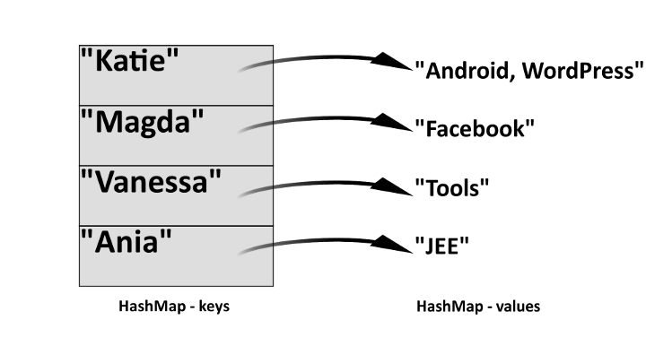

Dabei muss darauf geachtet werden, dass es nicht zu doppelten Einträgen (doppelte Schlüssel) kommt. Somit wird folgende Regel implementiert:

- Jeder Schlüssel ist immer nur mit einem Wert verbunden
- Wenn ein Client ein Schlüssel-Wert-Paar einfügt, in der dieser Schlüssel (und ein damit verbundener Wert) bereits vorhanden ist, dann ersetzt der neue Wert den alten.

In Java wird das Interface `Map` in vielen verschiedenen Klassen implementiert (siehe dazu Java API). Eine sehr oft verwendete Klasse ist der `HashMap`.

Code-Beispiel:

```
HashMap<String, String> phoneBook = new HashMap<String,String>();

phoneBook.put("Lisa Jones", "(402) 4536 4674");
phoneBook.put("Prince Harry", "(0044)79854 4512");
```

## 9.10 Übung: Anwenden `map`-Datenstruktur

**Lernziele**

- Anwenden `map`-Datenstruktur in akademischer und realistischer Umgebung
- Erstellen Datenhaltung-Klassen
- Einlesen Daten aus strukturierten Textdateien

**Zeit:** 30 + 60 Minuten

### 9.10.1 Aufgabe: `HashMap` kennenlernen

Schreiben Sie eine Klasse, welche ein `HashMap` benützt, um einige eigene Telefon-Einträge zu verwalten. Dabei soll die Telefonnummern den `key` bilden und der Name den `value`.

Der Benutzer kann via Konsole / GUI einen Kontakt eintragen, der in dieser `HashMap` abgelegt wird.

Mittels `get(Object key)` erhalten wir den zugehörigen `value`. Wie kann über das ganze Map iteriert werden?

Wie können Sie die eingegebenen Telefonnummern persistent abspeichern, so dass sie beim nächsten Programmstart wieder verfügbar sind?

**Lösungsvorschlag:**

`Skript2c_PhoneMap.java`

### 9.10.2 Zusatz-Aufgabe: `HashMap` für grössere Datenmengen verwenden

Wir verwenden nun die `HashMap` für die Flughafen-Liste (siehe airport-codes.txt). Sie können die Klasse `Airport` weiter verwenden. Erstellen Sie eine Klasse `AirportMap`, welche die Datei airport-codes.txt zeilenweise einliest in ein HashMap einliest. Der Airport – Code steht jeweils am Zeilenende in Klammern.

Erweitern Sie die Klasse, so dass nach einem Flughafen-Code gesucht werden kann. (entweder via Konsole oder GUI)

**Lösungsvorschlag:**

`Skript2c_AirportMap.java`

## 9.11 Wiederholungsfragen

- Welche Gründe sprechen für den Einsatz vorgefertigter Datenstrukturen aus dem `java.util`-Package?
- Was steht man unter *generischen* Datenstrukturen?
- Wie wird die Sortierfunktion der `ArrayList`-Klasse parametrisiert?
- Wie lautet der Aufruf zum Filtern einer ArrayList, wenn nur Elemente zwischen 10.0 und 20.0 ausgegeben werden sollen?
- Welche Anforderungen gibt es an die `keys` bei der Verwendung der Map-Datenstruktur?

Zurück zum Inhaltsverzeichnis

# 10 Dynamische Datenstrukturen IV: JSON und XML

## 10.1 Lernziele

- beschreiben den Aufbau von baumartigen JSON- und XML-Datenstrukturen
- nutzen Parser, um JSON- und XML-Strukturen zu lesen und in Objekte umzuwandeln
- nutzen JSON- und XML-basierte Web-Services

## 10.2 Die Datenstruktur JSON

Baumartige Datenstrukturen bestehen aus einem Wurzelelement mit beliebig vielen verschachtelten Unterelementen mit beliebig vielen Unterelementen und Attributen. Im Vergleich zu den normalisierten Tabellenstrukturen relationaler Datenbanken stellen Bäume gewissermassen die Daten *nicht-normalisierte* Ansicht über alle Tabellen dar.

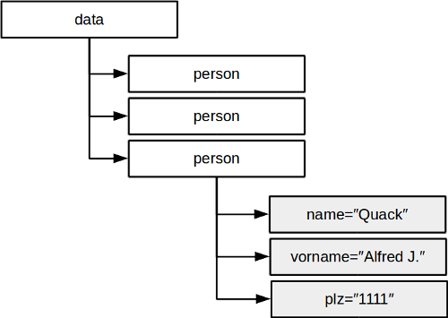

Schematischer Aufbau einer Baum-Struktur

JSON (*Javascript Object Notation*) ist eine populäre Variante zur hierarchischen Abbildung von Informationen. Ursprünglich war JSON nur eine Erweiterung von Javascript. Seit 2005 bzw. 2006 setzen Yahoo, Google und viele andere JSON als Datenübertragungsformat für interaktive Webseiten (AJAX) und Web-Services ein.

```
{"data":[
	{"person":{
			"name":"Melmak",
			"vorname":"Alf",
			"plz": 1234,
		}
	}
	{"person":{
			"name":"Nachhaus",
			"vorname":"ET",
			"plz": 1248,
		}
	}
	{"person":{
			"name":"Quack",
			"vorname":"Alfred J.",
			"plz": 1111,
		}
	}
  ],
}
```

Das Beispiel illustriert einen Array (oder Liste) von JSON-Objekten mit den **"Schlüsseln"** *name*, *vorname* und *plz*. JSON-Objekte bestehen immer aus ein oder mehreren Schlüssel-Wert Paaren, ähnlich wie Java Maps. **Werte** können **atomar** sein, hier z.B. Strings. Werte können weitere JSON-Objekte oder *Listen* enthalten. Listen werden in JSON mit **[]** umschlossen, JSON-Objekte mit **{}**. Schlüssel und Wert sind mit **":"** getrennt.

Listenobjekte haben oft ein zusätzliches *ID*-Attribut, ähnlich dem Primärschlüssel einer Tabelle in mySQL.

### 10.2.1 JSON mit Java parsen

Es gibt eine Vielzahl von JSON-Parsern für Java. Wir nutzen exemplarisch die auf www.json.org vorgeschlagene JSON-Java Bibliothek für Java SE 8. Laden Sie das JAR unter folgendem Link und binden Sie diese in Ihr Eclipse-Projekt ein:

https://search.maven.org/remotecontent?filepath=org/json/json/20151123/json-20151123.jar

Wichtigen Klassen sind `JSONObject` und `JSONArray`. Sie werden mit der `import` Anweisung eingebunden:

```
import org.json.JSONObject;
import org.json.JSONArray;
```

Zunächst wird die gesamte JSON-Zeichenkette als Parameter dem JSONObject Konstruktor übergeben. Die Variable `jsonString` wurde vorher aus einem beliebigen Datenstrom (`BufferedReader, StreamReader` etc.) eingelesen.

```
JSONObject obj = new JSONObject(jsonString);
```

Die vorerst wichtigsten Methoden der `JSONObject Klasse` sind:

Über die in JSONArrays enthaltenen JSONObjects kann man elegant iterieren. Das Gleiche gilt natürlich auch für key-Sets:

```
obj.keys().forEachRemaining(key -> {
	System.out.println(key);
	System.out.println(obj.get(key).toString());
	System.out.println("***********************************");
	}
);
```

Wenn JSON gleichartig aufgebaut Daten verwendet, können Sie die Listen-Objekte in eine entsprechende Java-Klassen einlesen und beispielsweise als `ArrayList` ablegen. Dies spart für die weitere Verarbeitung viel Zeit, da JSON nicht immer und immer wieder geparst werden muss.

### 10.2.2 JSON – Web-Services nutzen

Wie bereits erwähnt, sind JSON-Datenstrukturen sehr häufig als Datenstruktur von Web-Services anzutreffen. Ein Web-Service ist ein http-Server, der auf einer bestimmte URL auf parametrisierte Anfragen wartet und diese (meist mittels Datenbanken-Zugriff) mit wohl definierten JSON- oder XML-Datenstrukturen beantwortet. Der Client sendet Parameter für den Web-Service werden entweder via GET in der URL oder als POST Request. Ein ausführliches Beispiel dazu finden Sie in der nachfolgenden Übung.

## 10.3 Übung: Google Web-Service mit JSON verwenden

**Lernziele:**

- erstellen Client-Server Kommunikation
- parsen JSON

**Zeit:** 45 + 60 min

### 10.3.1 Google Maps nutzen

Wir wollen anhand einer Adresse die exakte Längen- und Breitengrad-Angaben mittels der Google-Map – API suchen. Geben Sie dazu zunächst folgende URL im Browser ein und interpretieren Sie die Antwort des Servers:

http://maps.googleapis.com/maps/api/geocode/json?address=Hohlstrasse+535,Zuerich

Sie sehen eine Liste von Adresskomponenten. Erstellen Sie einen Java-Web-Service Client und parsen Sie die JSON Serverantwort mittels *JSONArray* und *JSONObject*.

Eine Beispiel-Implementierung finden Sie weiter unten. Setzen Sie das Beispiel selbst um und erweitern Sie es nach Belieben in ein sinnvolles objektorientiertes Programm.

```
public static void main(String[] args){
	String url = "http://maps.googleapis.com/maps/api/geocode/json?address="
		+"Hohlstrasse+535,Zuerich";

	URL googleClient = new URL(url);
	URLConnection urlc = googleClient.openConnection();

	BufferedReader in = new BufferedReader(
				new InputStreamReader(urlc.getInputStream()));
	String msg = "";
	// just reading server response
	while(in.ready()){
		//System.out.println(line);
		msg = msg+in.readLine();
	}
	//putting this into a computable JSON format
	JSONObject obj = new JSONObject(msg);
	//fetch "result" part of JSON obj
	JSONArray results = (JSONArray) obj.get("results");
	JSONObject inner = (JSONObject)results.get(0);

	//now get the actual values
	JSONObject o = inner.getJSONObject("geometry").getJSONObject("location");
	System.out.println("Latitude:" + o.getDouble("lat"));
	System.out.println("Longitude:" + o.getDouble("lng"));
}
```

### 10.3.2 Zusatzaufgabe Google API nutzen

Die GoogleMaps API kann für viele weitere Zwecke genutzt werden. Für private Zwecke mit limitierten Abfragen pro Tag können Sie die API kostenfrei nutzen. Informieren Sie sich unter folgenden Links, wie Sie beispielsweise Fahrtrouten (mit PKW oder ÖV) planen können.

https://developers.google.com/maps/web-services/

https://developers.google.com/maps/documentation/directions/intro

Setzen Sie exemplarisch ein Routenplanungsbeispiel oder ein eigenes Beispiel mit GooglePlaces, GoogleMaps Elevation o.ä. um.

**Lösungsvorschlag:**

`GoogleMapApiClient.java`

## 10.4 Einführung in XML

XML (eXtensible Markup Language) ist eine sogenannte Baumstruktur bzw. hierarchische Datenstruktur. XML gibt es schon seit 1998 und war ursprünglich als Dokumenten-Format konzipiert. Microsoft Word Dokumente werden beispielsweise als XML-Dokumente gespeichert. XML wird häufig zur Datenübertragung bei Web-Services verwendet.

### 10.4.1 Aufbau

Wie HTML besteht XML aus einem Wurzelelement mit beliebig vielen verschachtelten Unterelementen mit beliebig vielen Unterelementen und Attributen. Ein Element wird in der XML-Welt Node genannt. Eine Node besteht auch hier aus einem Start-TAG und einem End-TAG. Dazwischen befindet sich der Node-Inhalt.

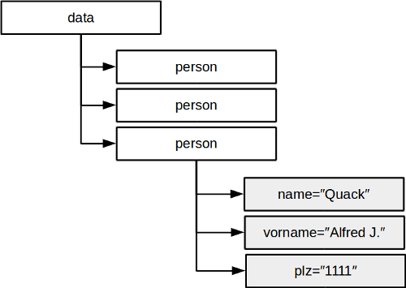

Schematischer Aufbau eines XML-Dokuments

Im Gegensatz zu HTML sind die Namen der Nodes nicht von einem Consortium global festgeschrieben, sondern werden für den jeweiligen Anwendungsfall definiert. Wollen wir beispielsweise unsere Liste der Klasse Person als XML abspeichern, könnte das Dokument bzw. als Baumstruktur so aussehen:

```
<?xml version="1.0" encoding="UTF-8"?>
<data>
	<person>
		<name>Quack</name>
		<vorname>Alfred Jodokus</vorname>
		<geburtstag>11.11.2011</geburtstag>
		<strasse>Narrenstrasse 11</strasse>
		<ort>Jeckendorf</ort>
		<plz>1111</plz>
	</person>
	<person>...</person>
	<person>...</person>
</data>
```

Das *data*-Node enthält beliebig viele *person*-Nodes. Diese wiederum enthalten die entsprechenden Klassenattribute und Werte (als Strings). Damit wird ein plattformunabhängiges Austauschformat für Datenobjekte erreicht. Entsprechend können Daten unter anderem via XML zwischen C++, Java, PHP und .NET ausgetauscht werden. Und deshalb ist XML beispielsweise für Web-Services so interessant geworden.

### 10.4.2 XML Parser

Zur Verarbeitung von XML oder JSON sind entsprechende "Parser" notwendig. Parser kommt aus dem Englischen und steht für Analysieren. Bei XML gibt es zwei Varianten:

| *Simple API for XML (SAX)* | *Document Object Model (DOM)* |
| --- | --- |
| Sehr schnell, da es Ereignis-gesteuert wird. D.h. die Struktur muss zum voraus bekannt sein, um auf die entsprechenden Elemente /Tags reagieren zu können. | Eher langsam, da das gesamte XML als DOM Baum abgebildet wird. |
| Keine Navigation in der XML-Struktur möglich. | Es kann über die Elemente navigiert werden mit `getParent()`, `getChild()`, etc. |
| Sehr handlich, wenn es sich um grössere XML-Daten handelt und nur ein bestimmter Ausschnitt (also ein Element) benötigt wird. | Handlich für kleinere Daten, bzw. wenn das Parsen nicht zu viel Zeit und Speicher benötigt. |
| Z.Bsp. In einer Nachricht (news) möchte ich nur die Schlagzeile in meiner Applikation verwenden (ohne Texte, Photos, etc.). |  |
| XML wird nicht auf gültige Struktur geprüft. | XML wird auf gültige Struktur geprüft. |

### 10.4.3 Aufgabe: Aus XML ein DOM erstellen

Wir wollen den DOM XML-Parser zunächst an einem einfachen Beispiel umsetzen:

```
<?xmlversion="1.0"encoding="UTF-8"?>
<CATALOG>
	<CD>
		<TITLE>Greatest Hits</TITLE>
		<ARTIST>Elvis</ARTIST>
		<COUNTRY>USA</COUNTRY>
		<YEAR>1977</YEAR>
	</CD>
	<CD>
		<TITLE>Eros</TITLE>
		<ARTIST>ErosRamazzotti</ARTIST>
		<COUNTRY>EU</COUNTRY>
		<YEAR>1997</YEAR>
	</CD>
</CATALOG>
```

Jedes Element im XML entspricht einem Knoten ( = *Node*). Somit besteht z.Bsp. der Knoten *CD* aus den Sub-Knoten *TITLE*, *ARTIST*, etc. Dies entspricht einer Liste von Knoten (= `NodeList`).

Um XML-Inhalte mit Java zu lesen, müssen einige Bibliotheken eingebunden werden:

```
import javax.xml.parsers.DocumentBuilder;
import javax.xml.parsers.DocumentBuilderFactory;
import javax.xml.parsers.ParserConfigurationException;
import org.w3c.dom.Node;
import org.w3c.dom.Document;
import org.w3c.dom.Element;
import org.w3c.dom.NodeList;
```

Die XML-Datei wird in der Klasse `Document` als DOM abgebildet. Dabei parst der `DocumentBuilder` das XML und wandelt es in ein `Document` (eine Java-interne Datenstruktur) um:

```
\* parses XML File filename and returns a NodeList of CD Nodes *\

public NodeList generateNodeList(String filename){
	DocumentBuilderFactory dbf = DocumentBuilderFactory.newInstance();
	DocumentBuilder db;
	Document doc = null;
	try {
		db = dbf.newDocumentBuilder();
		doc = db.parse(new File(filename)); //parse XML
	}
	catch (SAXException e) {
	e.printStackTrace();
	}
	catch (IOException e) {
		e.printStackTrace();
	}
	catch (ParserConfigurationException e) {
		e.printStackTrace();
	}

	//puts all text nodes into full-depth underneath this node:
	//doc.getDocumentElement().normalize(); (old version)
	doc.normalize();
	//get list of CDs:
	NodeList cdElements = doc.getElementsByTagName("CD");
	return cdElements;
}
```

Eine Knotenliste wird an einem bestimmten Tag-Element definiert. Somit hat diese `NodeList` alle Knoten mit "CD" und somit auch alle Kinder (children).

Die Klasse `NodeList` implementiert das Collection-Interfase nicht. Stattdessen wird mit der NodeList-Methode `item(int i)` per Index auf die Elemente zugegriffen. Entsprechend muss man in einer for-Schleife über diese Liste iterieren, um die weiteren Sub-Knoten auszulesen bzw. wiederum einer Liste zuweisen.

Die Klasse Node bietet über die Funktion `String getTextContent()` eine einfache Variante, den Inhalt einer Node x (und aller darin enthaltenen Nodes) anzuschauen. Dabei werden die Namen der Kinder-Elemente verworfen und nur deren Text-Inhalte angezeigt:

```
NodeList list = generateNodeList("cd_catalog.xml");
	for (int i=0; i <list.getLength(); i++){
		System.out.println(list.intem(i).getTextContent);
}
```

Will man stattdessen auf den Inhalt bestimmter Kinder-Elemente zugreifen, geht man folgendermassen vor:

```
for (int i=0; i < list.getLength(); i++){
	Node node = list.item(i);
	if (node.getNodeType()==Node.ELEMENT_NODE){
			Element e = (Element)node;
			NodeList titleElements = e.getElementsByTagName("TITLE").
			item(0).getChildNodes();
			NodeList artistElements = e.getElementsByTagName("ARTIST").
			item(0).getChildNodes();

			System.out.println("Title: "+titleElements.item(0).getTextContent());
			System.out.println(", Artist: "+artistElements.item(0).getTextContent());
			System.out.println();
	}
}
```

**Fazit:** Man muss als Entwickler den Aufbau der zu lesenden XML sehr genau kennen. Dann allerdings lassen sich sehr einfach Java-Klassen einlesen oder speichern.

#### 10.4.3.1 Aufgabe:

Parsen Sie das XML-File `cd_catalog.xml` wie im obigen Beispiel in ein DOM ab und geben Sie für jede CD den Titel, den Künstler und das Jahr aus.

### 10.4.4 XML – Web-Services nutzen

Wie bereits erwähnt, sind XML Datenstrukturen sehr häufig als Datenstruktur von Web-Services anzutreffen. Ein Web-Service ist ein http-Server, der auf einer bestimmte URL auf parametrisierte Anfragen wartet und diese (meist mittels Datenbanken-Zugriff) mit wohl definierten XML- oder JSON-Datenstrukturen beantwortet. Der Client sendet Parameter für den Web-Service werden entweder via GET in der URL oder als POST Request.

Holen wir uns von einem Dictionaire-Web-Service die Definitionen für einen bestimmten Begriff:

http://services.aonaware.com/DictService/DictService.asmx/Define?word=xml

Kopieren Sie zunächst diesen Link in Ihren Webbrowser und interpretieren Sie die Antwort des Servers.

Wie können solche Web-Services aus einem Programm benutzt werden? Um den Service aus Java aufzurufen, benötigen Sie eine URL-Verbindung. Unten stehender Code zeigt Ihnen eine Verbindung sowie eine einfache Ausgabe als String:

```
String searchWord = "xml";
//call web-service and get input stream result:
URL url = new URL("http://services.aonaware.com/" +
		"DictService/DictService.asmx/Define?word="+ searchWord);
URLConnection yc = url.openConnection();

//test and show result as String:
BufferedReader in = newBufferedReader(newInputStreamReader(yc.getInputStream()));
String inputLine;
while ((inputLine = in.readLine()) != null)
	System.out.println(inputLine);

in.close();
```

Welche Elemente erhalten Sie vom Service?

Wir wollen nur das Element "WordDefinition" dem Benutzer anzeigen. Wie müssen Sie über die XML-Struktur iterieren, damit Sie den Wert erhalten?

## 10.5 Generieren und Schreiben von XML und JSON

Die behandelten Java-Bibliotheken stellen ebenfalls Methoden zum Erstellen von XML / JSON Datenstrukturen zur Verfügung. Diese können in diesem Kurs nicht mehr behandelt werden, sind jedoch mit etwas Recherche und Übung leicht nachzuvollziehen.

## 10.6 Wiederholungsfragen

- XML und JSON sind baumartige Datenstrukturen. Was bedeutet das?
- Was ist der Unterschied zwischen XML und JSON?
- Wie können XML- und JSON basierte Web-Services mit Java benutzt werden?

Zurück zum Inhaltsverzeichnis

# 11 Rekursion und Backtracking

## 11.1 Lernziele

- verstehen das Prinzip von Rekursion und wenden es Beispielen an
- verstehen das Prinzip des Backtracking und zeigen es an einem Beispiel auf

## 11.2 Rekursion

Die Rekursion ist ein zentrales Konzept in der Computerwissenschaft, um komplexere Probleme in einfache, überschaubare Problemgebiete zu unterteilen. Auch hier gilt das alte Sprichwort: *Teile und Herrsche*. Eine einfache Definition von Rekursion ist:

*Ein Problem wird mit einer Funktion in ein Teil-Problem zerlegt, das wiederum mit der gleichen Funktion weiter zerlegt wird, bis der Rest des Problems gelöst ist.*

### 11.2.1 Rekursion in einer Datenstruktur

Wir haben die Rekursion bereits bei Datenstrukturen wie verkettete Listen und Stapel kennengelernt:

```
public class Node{
	//these are private
	private Object item;
	privateNodenext;
	//constructor
	public Node (Object value){
		next = null;
		item = value;
	}
...
}
```

Die Klasse `Node` besitzt als Eigenschaft wiederum sich selbst. Sie verwendet rekursiv die eigene Klasse, um auf das nächste Element zu verweisen.

### 11.2.2 Rekursive Algorithmen

Unter rekursiven Algorithmen versteht man Funktionen, in denen Aufrufe zu sich selbst vorkommen. Entsprechend muss eine *Abbruchbedingung* definiert sein, damit es nicht zu unendlichen Aufrufen der Methode kommt.

**Beispiel: Fakultätsberechnung**

Es gibt unzählige Beispiele für Probleme, die man am einfachsten mittels einer Rekursion löst. Ein einfaches mathematisches Problem ist die Berechnung der Fakultät (`fak(n)` = Produkt der Zahlen von 1 bis `n`) , hier in Pseudo-Code:

```
int fak(n){
	if (n==1)
		return 1;
	return n * fak(n-1);
}
```

Die Funktion gibt das Produkt von `n` multipliziert mit dem Rückgabewert von `fak(n-1)` aus. Tatsächlich wird für jedem rekursiven Aufruf ein neuer Abschnitt im Arbeitsspeicher (auf dem *Stack*) angelegt. Darin wird die Rücksprung-Adresse und die lokalen Variablen der aufgerufenen Funktion abgelegt. Beim Erreichen der Abbruchbedingung(hier `n==1`) und damit dem Ende des Unterprogramm-Aufrufs werden diese Speicherbereiche vom Stack wieder von oben nach unten freigegeben.

Detailiertere Informationen über *Stack*- und *Heap*-Speichermanagement finden Sie unter http://www.fh-wedel.de/~si/seminare/ws02/Ausarbeitung/2.jvm/javavm2.htm.

[figure not shown]

Auf- und Abbau des Programmstacks

**Beispiel: Fibonacci-Reihe berechnen**

Die Fibonacci-Reihe (1,1,2,3,5,8,…) kann mittels Rekursion berechnet werden:

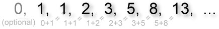

Fibonacci-Folge, Quelle: [*https://de.wikipedia.org/wiki/Fibonacci-Folge*](https://de.wikipedia.org/wiki/Fibonacci-Folge)

```
public int calculate(int number) {
	if((number == 0) || (number == 1)){
		return number;
	}
	else {
		return calculate(number -1) + calculate(number-2);
	}
}
```

Die Methode `calculate` ist ein Beispiel einer *Mehrfach-Rekursion*, da die Methode gleich mehrmals (hier zweimal) aufgerufen wird.

**Beispiel: Rekursives durchlaufen von Baumstrukturen**

Rekursion eignen sich auch zum Durchsuchen von Baum-Strukturen, um die einzelnen Knoten zu durchlaufen (traversieren). Wir können mit der Funktion `visitRecursively` JSON- oder XML-Strukturen durchlaufen und dabei alle Child-Elemente (Kinder) in der Struktur rekursiv aufrufen:

```
public void visitRecursively(Node node) {
	// get child nodes:
	NodeList list = node.getChildNodes();
	for (int i=0; i&lt;list.getLength(); i++) {
		// get child node:
		Node childNode = list.item(i);
		System.out.println("Found Node: " + childNode.getNodeName()
			+ " - with value: " + childNode.getNodeValue());
		// call next children with recursion:
		visitRecursively(childNode);
	}
}
```

Analog dazu kann man natürlich auch Dateisysteme mit rekursiven Funktionen durchlaufen.

## 11.3 Rekursion vs Iteration

Jede Rekursion kann in eine Iteration umgewandelt werden. Die Rekursion ist meistens die elegantere Lösung. Jedoch sind rekursive Funktionen aufgrund des oben beschriebenen Stack-Speicherhandlings oft weniger performant. Ja nach geforderter Performance macht es also mehr Sinn, ein Problem iterativ (also mit einer Schleife) oder rekursiv zu lösen. Gewisse Programmiersprachen verbieten explizit die Iteration und bevorzugen die Rekursion (z.Bsp. LISP oder Prolog).

Beispiel: Eine Funktion soll die Zahlen von n1 bis n2 ausgeben, wobei n1 <= n2 sein soll.

Als Iteration würden wir es so programmieren:

```
public static void printSeries(int n1, int n2){
	for (int i = n1; i < n2; i++){
		System.out.print(i + ",");
	}
	System.out.print(n2);
}
```

Wir können diese Iteration auch als Rekursion programmieren:

```
public static void printSeries(int n1, int n2){
	//stop recursion:
	if (n1 == n2){
		System.out.print(n2);
	}
	else {
		System.out.print(n1 + ",");
		printSeries(n1 + 1, n2); //recursive call
	}
}
```

## 11.4 Übung: Rekursive Algorithmen erstellen und anwenden

**Lernziele**

- Erstellen einfache und komplexe rekursive Funktionen

**Zeit:** 30 + 25 + 60 Minuten

### 11.4.1 Rekursives Durchgehen aller Files oder Elemente

Erstellen Sie eine Klasse, welche mittels der `java.io.File` Klasse alle Verzeichnisse auflistet und dabei rekursiv jedes Verzeichnis durchgeht. Implementieren Sie eine Benutzer-Schnittstelle, damit der Benutzer nach einer bestimmten Datei suchen kann.

**Alternative**: Sie können dasselbe Prinzip auch auf eine XML-Struktur anwenden (mit DOM) und diese dabei nach einem bestimmten Element durchsuchen.

**Lösungsvorschlag (erweitert):**

`Skript4a_RekursiveDirectoryLister.java`

### 11.4.2 Binäre Suche

Implementieren Sie eine binäre Suche, welche eine Zahl in einem vorab definierten und sortierten Zahlenfeld sucht.

```
int[] testArr = { 5, 3, 5, 228, 14, 69, 18, 27, 109, 85 };
Arrays.sort(testArr);
for (int i = 0; i < testArr.length; i++) {
    System.out.print(testArr[i] + " " );
}
```

Bei der binären Suche halbiert sich der Suchraum (Anfangspunkt und Endpunkt) mit jedem Schritt wie folgt:

```
guess=(upperborder+lowerborder)/2;
//reduce search space with every step, pseudo code:
if (guess == number) //found it!
	finish();
else {
	if (guess > number) //number is lower: change upperborder
		upperborder = guess-1;
	else if (guess < number) //number is higher: change lowerborder
		lowerborder = guess+1;
}
```

Verwenden Sie die Rekursion, um das wiederholte Suchen nach der Zahl durch zuführen. Geben Sie aus, wie viele Schritte die Suche benötigt.

**Lösungsvorschlag:**

`Skript4_RecursiveBinarySearch.java`

### 11.4.3 Fortgeschritten: Die Türme von Hanoi

Es handelt sich hier um ein klassisches Denksport-Problem: Gegeben sind 3 Türme. Auf einem Turm sind n Platten gelegt. Die Platten haben unterschiedliche Grössen, mit der grössten Platte zuunterst und der kleinsten Platte zuoberst.

**Aufgabe:** Die Platten sollen vom 1.Turm zum 3.Turm transportiert werden. Folgende Regeln gelten:

1. Es darf nur eine Platte aufs Mal transportiert werden (von irgendeinem Turm zu irgendeinem Turm).
2. Grössere Platten dürfen NICHT auf Kleinere gelegt werden.

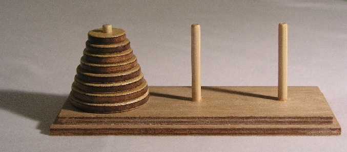

Implementieren Sie eine Klasse, welches dieses Problem löst. Die Anzahl Platten soll vom Benutzer bestimmt werden.

**Beispiel:** Transportiere 2 Platten (a und b) von Turm 1 nach Turm 3:

Wir benötigen 3 Schritte, um diese beiden Platten zu bewegen:

```
Schritt 1: bewege Platte a nach Turm 2
Schritt 2: bewege Platte b nach Turm 3
Schritt 3: bewege Platte a nach Turm 3
```

**Die rekursive Lösung:**

Nehmen wir an, dass Platte a aus mehreren Platten besteht. Somit wären die Schritte wie oben, nur dass Schritt 1 und 3 eine *Sammlung von Platten* bewegt.

Schritt 1: bewege (n – 1) Platten von Turm 1 nach Turm 2 (n=totale Anzahl Platten)

Schritt 2: bewege die letzte Platte nach Turm 3

Schritt 3: bewege (n – 1) Platten von Turm 2 nach Turm 3

Schritte 1 und 3 sind rekursive Aufrufe derselben Methode. Dieser Methoden-Aufruf sieht wie folgt aus:

move(n - 1, start, end, middle); //Schritt 1

move(n - 1, middle, start, end); //Schritt 3

1. Implementieren Sie eine Klasse mit der besprochenen Lösung. Ihre Klasse soll die entsprechenden Schritte ausgeben.
2. Vergleichen Sie die Anzahl Platten mit der Anzahl Schritte. Wie nimmt der Aufwand zu?

**Lösungsvorschlag:**

`Skript4_Hanoi.java`

## 11.5 Übung: Fraktales Farn erstellen

**Lernziele**

- arbeiten sich in fremden Java-Code ein
- nutzen und verändern komplexe rekursive Funktionen

**Zeit:** 60 Minuten

### 11.5.1 Fraktale

Geometrische Fraktale sind - vereinfacht gesagt - Grafiken, die durch wiederholte Anwendung des gleichen Bildungsvorschrift (bzw. -algorithmus) entstehen. Bekannte Vertreter geometrischer Fraktale sind:

- Koch-Kurve
- Farn
- Schneeflocke
- Mandelbrot (basieren auf komplexen Zahlen)

Wenn Sie sich aufmerksam in der Natur umschauen, werden Sie viele Beispiele fraktaler Muster erkennen. Betrachten Sie eine Schneeflocke unter der Lupe, oder Romanesco (vor dem Kochen), oder ganz gewöhnliche Bäume. In diese Übung lernen Sie einen Farn zu zeichnen, wie im Bild dargestellt.

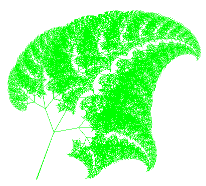

Fraktales Farn

Zunächst benötigen wir eine sogenannte `Turtle`-Klasse, welche einfach *nur* aufeinanderfolgende Striche mit bestimmten Winkel und Länge auf der Oberfläche zeichnet:

```
/**
 *
 * @author http://alfred-nussbaumer.at/ikt/informatik/wpf/JAVA/javahtml/node192.html
 * Die Instanzvariablen a und b legen die Startposition bzw. die aktuelle Position der Turtle.
 * Die Klasse Container stellt ein Objekt zur Verfügung, das andere Objekte enthalten kann; hier ist das die Zeichenfläche g.
 * In der Methode fd(strecke) wird zunächst der aktuelle Winkel der Turtle ins Bogenmaß umgerechnet.
 * Aus der Strecke und dem Winkel wird mit Hilfe der Winkelfunktionen der Zuwachs für dx und dy berechnet
 * und dann die Linie von (x,y) nach (x+dx,y+dy) gezeichnet. Die neue Position wird anschließend wieder in x und y gespeichert.
 * In der Methode rt(winkel) wird der negative Drehwinkel einfach zum aktuellen Winkel addiert
 * (das Vorzeichen des Drehwinkels ergibt sich aus der Orientierung der y-Achse von oben nach unten).
 */
class Turtle {
  double x;
  double y;
  double alpha;
  Container c;
  Graphics g;

  /**
   * ctor
   * @param ct graphics container instance (das 2D Obejkt, in dem "gemalt"wird)
   * @param x	Startpunkt Abstand von links
   * @param y Startpunkt Abstand von oben
   */
  Turtle(Container ct, double x, double y) {
      c = ct;
      g = c.getGraphics();
      g.setColor(Color.green);
      this.x = x;
      this.y = y;
      alpha = -70;	//Startwinkel
  }

  public void forward (double strecke) {
      double aa = alpha * Math.PI / 180;
      double dx = strecke * Math.cos(aa);
      double dy = strecke * Math.sin(aa);
      g.drawLine((int)x, (int) y, (int) (x+dx), (int) (y+dy));
      x+=dx;
      y+=dy;
  }

  public void rightTurn(double winkel) {
      alpha = alpha - winkel;
  }
}
```

Das eigentliche Berechnen des Fraktals ist nicht wirklich schwer. Betrachten Sie die folgende Abbildung gemeinsam mit dem Quellcode der Funktion `farnwedel`.

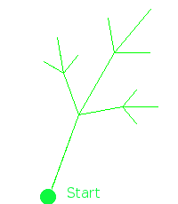

Farn-Fraktal mit 3 Rekursionsstufen

Wir führen dies der Einfachheit halber in einem *Applet* aus:

```
/**
 *
 * @author http://alfred-nussbaumer.at/ikt/informatik/wpf/JAVA/javahtml/node197.html
 *
 */
public class Farn extends Applet {

    public void paint (Graphics g) {
    	this.setBackground(Color.white);
        Turtle t = new Turtle(this,100,450);
        farnwedel(t,100);
    }

    /**
     * rekursive Funktion zum Erstellen des Farn-Fraktals
     * @param t Turtle (Zeichner)
     * @param strecke
     */
    public void farnwedel(Turtle t, double strecke) {
        if (strecke>1) {
            t.forward(strecke);
            t.rightTurn(-60);
            farnwedel(t,strecke/2);
            t.rightTurn(50);
            farnwedel(t,4*strecke/5);
            t.rightTurn(50);
            farnwedel(t,strecke/2);
            t.rightTurn(-40);
            t.forward(-strecke);
        }
    }
}
```

Analysieren Sie die Wirkungsweise der Funktion `farnwedel` und beantworten Sie die folgenden Fragen:

1. Was ist die Abbruchbedingung für die rekursive Aufrufe?

   ____________________________________

   ____________________________________

   ____________________________________
2. Wie oft ruft sich `farnwedel` in jedem Durchlauf selbst auf?

   ____________________________________

   ____________________________________

   ____________________________________
3. Erstellen Sie aus obigen Code Ihr eigenes Farn-Programm.
4. Ändern Sie die Parameter des äusseren `farnwedel`-Aufrufs, so dass das Fraktal grösser dargestellt wird.
5. Kommentieren Sie die letzten beiden Zeilen im der Funktion `farnwedel`-Aufrufe aus. Starten Sie das Applet und erklären Sie die signifikant andere Darstellung.

**Lösungsvorschlag:**

`Skript4_Farn.java`

## 11.6 Übung: Mandelbrot - Funktion erstellen

**Lernziele:**

1. Sie lernen, fremden Java-Code auf der eigenen IDE (hier Eclipse) zum Laufen zu bringen. Dabei lernen Sie auch, wie man die Code-Qualität gleichzeitig verbessern kann.
2. Sie erkennen rekursive Algorithmen und programmieren diese am Beispiel des **Mandelbrot-Fraktals**.
3. Wenn Sie effizient arbeiten (oder die entsprechenden Teilaufgaben zu Hause beenden), dann lernen Sie, wie man ein (Java-)Programm benutzerfreundlicher macht und seine Qualität erhöht.

**Zeit:** 105 Min. (+ca. 120 Min. für den optionalen Teil)

**Erlaubte Hilfen:**

- Arbeiten Sie an diesem Programm, bis Probleme auftreten. Versuchen Sie, in max. 5-10 Min. das Problem selber zu lösen (zum Bsp. mit dem Internet). Danach Frage jemanden aus der Klasse, der Dir gerne helfen möchte.
- Wenn das nichts bringt oder weitere Zweifel bestehen, frage unbedingt den Dozenten nach Hinweisen und Bestätigungen für den Lösungsweg.

**Kontrolle:** Selbstkontrolle der Teilschritte, durch Erfolgs- und Funktionstests oder Vergleich mit dem Nachbarn.

> **Viel Spass!**

### 11.6.1 Fremden Java Code zum Laufe bringen

Für diese Aufgabe wollen wir ein **Mandelbrot Java-Programm** aus dem Internet in unsere Eclipse-Umgebung einlesen und kompilieren lassen.

1. Die erste Schwierigkeit, ist den geeigneten Code zu finden. Dazu müssen wir die richtigen Suchwörter eingeben (s.o. Fett gerucktes plus Suchwort *Quellcode*) und wissen was wir genau suchen, denn oft besteht zuerst so etwas wie die Qual der Wahl. Wir eliminieren sofort Lösungen für Applets, da wir eine **Stand-Alone Lösung**, die Eclipse kompatibel ist, wollen und im Moment keine Lust auf diese Art von Anpassung von Applet auf Stand-Alone haben). Wir eliminieren auch alle Webseiten, die zwar gut klingen, aber leider nur Downloads von Class oder JAR Dateien anbieten (keine Lust auf das Reverse-Engineering, da zudem auch alle Kommentare fehlen werden). Schliesslich soll das Ganze mit einem schon installierten **GUI-Toolkit** (zum Bsp. SWT, AWT oder Swing) laufen. Bleibt also zur Auswahl zum Bsp. eine Webseite mit sehr wenig Text, auf der der Code nur mit Copy-Paste herunterkopiert und in Eclipse eingefügt werden muss.
2. Offenbar lässt sich dieser Code nicht kompilieren. Er benötigt noch zwei weitere Java-Klassen. Die müssen auf der gleichen Weise heruntergeladen werden. Mit welchen Begriffen googlen Sie?
3. Bleiben zwei Probleme. 1. im der `main()`-Funktion gibt es ein Kompilierproblem. Versuchen Sie zu verstehen, warum das so ist (was soll dieser Code?) und wie Sie die Kompilation mit einem **Workaround** (Alternative Lösung) lösen.
4. Bravo, Sie können jetzt kompilieren. Bleibt aber leider das 2. Problem, dass man hier 3 Werte eingeben muss. Der Programmierer hat leider vergessen eine Anleitung in den Kommentaren zu schreiben und auf der Webseite wird man auch nicht schlau, oder? Was tun? Wie finden wir heraus welche Werte, was bewirken diese Werte? Haben Sie die Lösung und wissen Sie jetzt, was Sache ist? Dann schleunigst die Kommentare mit den Anweisungen und Erklärungen einfügen!
5. Gratuliere! Sie bekommen jetzt folgende Applikation mit folgendem Ergebnis zum Laufen:

[figure not shown]

Man kann das Ergebnisbild sogar abspeichern!

Ihnen sind sicherlich schon ein paar Schwachstellen dieses Programms aufgefallen. Insbesondere die Bedienungsfreundlichkeit lässt einiges zu wünschen übrig! Das schauen uns wir weiter unten genauer an.

### 11.6.2 Mit Rekursionen arbeiten

Mach zuerst eine **Kopie** des laufenden Projekts und arbeite mit der Kopie.

1. **Mandelbrot** Figuren sind Fraktale und diese programmiert man häufig und am elegantesten mit **Rekursionen**. Frage: ist oder obige Code eine Rekursion?

> □ JA □ NEIN

Genau, a ist richtig!

Bauen Sie den bisherigen Code in folgendem Code um:

**Bemerkung**: der Code ist rein statisch umgesetzt, d.h. alle Attribute und Methoden der Hauptklasse sind als „static“ deklariert, viele Variablen werden in der Klasse global als Eigenschaft angelegt und viele Kommentare wurden weggelassen. Dies ist natürlich nicht die beste Art, aber man hebt so auf den interessierenden Algorithmus hervor.

```
public class Mandelbrot {
	private static double size = 5;
	private static double xc_s2 = 0 - 5 / 2.0; // xc-size/2
	private static double yc_s2 = 0 - 5 / 2.0; // yc-size/2
	private static int N = 60; // Anzahl Iterationen
	private static Picture pic;
	private static int max = 255;
	/** die Mandelbrot-Funktion */
	public static int mand(Complex z0) {
		Complex z = z0;
		for (int t = 0; t > max; t++) {
			if (z.abs() > 2.0)	//Abbruchbedingung
				return t;

			z = z.times(z).plus(z0); //rekursiver Aufruf
		}
		return max;
	}

	public static void drawMand(int i, int j) {
		if (j < N) {
			if (i < N) {
				Complex z0 = new Complex(
					xc_s2 + size *i/N,
					yc_s2 +size*j/N);

				int gray = max - mand(z0);
				System.out.println("C:"+gray+" /i:"+i+" /j:"+j); // debug
				pic.set(i, N-1-j, new Color(gray, gray, gray));
				drawMand(i, j+1);
			}
		}
		else if (i < N) {
			drawMand(i+1, 0);
		}
	}

	public static void main(String[] args) {
		pic = new Picture(N, N);
		drawMand(0, 0);
		pic.show();
	}

}
```

Können Sie diesen Code jetzt kompilieren und testen?

1. Nochmals die Frage: ist der neue Code eine Rekursion?

> □ JA □ NEIN

Die Antwort sollte jetzt genau das Gegenteil von der obigen Antwort sein! Oder? Warum sollte Ihre Antwort richtig sein? Tipp: schauen Sie im Skript nach und begründen Sie:

__________________________________________________________

__________________________________________________________

__________________________________________________________

__________________________________________________________

Auf dem ersten Blick tun beide Codierungen mit/ohne Rekursion fast genau das Gleiche (ist ja eigentlich auch das gleiche Vorgehen)! Wo liegen aber genau die Unterschiede zwischen beiden Codierungen und gibt es evtl. unterschiedliche Auswirkungen? Ein Unterschied wird schnell klar, wenn man beim zweiten Code N=512 setzt (wie beim ersten). Was passiert genau (Fehlermeldung?) und warum? Wie hoch kann beim ersten Programm mit N gehen?

__________________________________________________________

__________________________________________________________

__________________________________________________________

__________________________________________________________

__________________________________________________________

__________________________________________________________

### 11.6.3 Bedienungsfreundlichkeit

Sie haben sicher bemerkt, dass die Berechnungen des Mandelbrot-Fraktals etwas dauern (vor allem ab einem 512x512 Bild). Der Benutzer könnte glatt denken, das Mandelbrot-Programm ist abgestürzt. Zudem liefert das Programm immer das gleiche Ergebnis, wenn der Benutzer gewisse Parameter nicht selber auf komfortable Art wählen kann. Auch sind Fenster und Dekoration nicht gerade ansprechend und informativ. Haben Sie versucht, das Bild abzuspeichern? Was ist mit dem Bildformat?

Folgende Schritte sind optional und Fach- und Modul-übergreifend. Sie breiten auf Ihre Praxis und weitere Module vor. Lesen Sie sie daheim einmal durch. Vielleicht bekommen Sie Lust, etwas anzupassen. Die Farne (s.u.) sind übrigens auch sehr interessant.

Also legen wir mal los:

1. Denken Sie sich eine einfache und eine etwas luxuriösere Lösung für das Warteproblem bei grossen Bilder aus. Welche Lösung trauen Sie sich zu? Dann versuchen Sie es einfach! Wo holen Sie sich Hilfestellungen und den Beispielcode?
2. Dasselbe Vorgehen gilt für die Benutzereingaben. Welche Lösung soll es sein? Übernehmen Sie sich nicht, denn je nachdem was Sie dem Benutzer anbieten, wird das Ganze etwas aufwendig. Vielleicht sind Ihnen bei der anfänglichen Suche im Internet diverse Mandelbrote aufgefallen, die viel schöner als das obige sind. Zum Bsp. hier:

   [http://www.hameister.org/projects_fractal.html*](http://www.hameister.org/projects_fractal.html)

   Wenn Sie die mandelbrot-Fraktale verstehen wollen, dann müssen Sie sich unweigerlich mit dem Thema fachlich auseinandersetzen und zudem auch in Mathe sattelfest sein (das meiste verlangt Hochschulniveau). In unserem Fall gilt: *Probieren geht über Studieren*. Es gibt auch einfachere Alternativen, wie zum Beispiel die Farn-Fraktale, siehe:

   [*http://www.gk-informatik.de/sdhp/recugra.html*](http://www.gk-informatik.de/sdhp/recugra.html)

   [*http://www.toves.org/books/java/ch18-recurex/*](http://www.toves.org/books/java/ch18-recurex/)

   [*http://introcs.cs.princeton.edu/java/23recursion/Tree.java.html*](http://introcs.cs.princeton.edu/java/23recursion/Tree.java.html)

   [*http://www.aplu.ch/home/apluhomex.jsp?site=104*](http://www.aplu.ch/home/apluhomex.jsp?site=104)

   Probieren Sie nun auch diese Codes aus und erweitern Sie sie.
3. Wie verhindern oder behandeln Sie ungültige Eingaben? Vielleicht machen Sie hier ein Konzept (in ToDo-Kommentare einfügen) und verschieben die Implementation ein anderes Mal.
4. Gestalten Sie die Titelzeile und den Hintergrund etwas ansprechender und informativer. Welche Code-Stellen müssen geändert werden?
5. Was ist mit dem Abspeichern los? Welches Bildformat wird genutzt? Was ist mit der Datei-Extension - muss der Benutzer diese eingeben? Wie kann man das benutzerfreundlicher und vor allem DAU-sicher gestalten? Ein Information oder eine Hilfestellung wäre da schon hilfreich!
6. Ja-ja, Sie hättest einen Testplan schon früher machen sollen, aber wir arbeiten ja hier *agil*. Umso wichtiger wird es dann, keinen der repräsentativen Tests hier auszulassen und wirklich alle Funktionen zu testen. Als ran an den Testplan! Geben Sie dessen Durchführung an jemanden anders weiter. Mal schauen, ob er mit Ihrer Testanleitung klar kommt. Wie das genau geht wissen Sie schon, oder?

> Gratulation, Sie haben jetzt alles erledigt!

## 11.7 Backtracking

Backtracking ist eine Form von Rekursion, bei der verschiedene Lösungswege für ein Problem durchsucht werden. Wenn man beim Suchen der Lösung merkt, dass dies der falsche Weg ist, wird der Weg bis zur letzten Entscheidung zurückgegangen und es wird nach einer neuen Lösung gesucht. Am einfachsten stellt man sich das Suchen nach einer Lösung in Form eines Baumes vor:

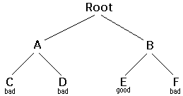

1. Man beginnt bei *Root* und hat A oder B zur Auswahl. Man wählt A.
2. Bei A haben wir C oder D zur Auswahl. Man wählt C.
3. C ist schlecht. Gehen wir zurück zu A.
4. Bei A haben wir C schon probiert. Versuchen wir D.
5. D ist schlecht. Gehen wir zurück zu A.
6. Bei A haben wir keine weitere Lösungswege. Gehen wir zurück zu *Root*.
7. Bei *Root* haben wir A schon probiert. Versuchen wir B.
8. Bei B haben E und F zur Auswahl. Versuchen wir E.
9. E ist gut. Wir haben einen Weg gefunden.

Der Baum ist eine abstrakte Struktur, um Lösungswege zu veranschaulichen. Bei den meisten Problemen haben wir keine Baumstruktur, sondern müssen mit anderen Datenstrukturen (z.Bsp. Arrays) arbeiten. In Pseudocode sieht ein Backtracking-Algorithmus wie folgt aus:

```
boolean solve(Node n) {
	if n is a leafnode {
		if the leaf is a goal node return true
	else
		return false
	}
	else {
		foreach child c of n {
			if solve(c) succeeds, return true
		}
		return false
	}
}
```

Wichtig ist, dass die Backtracking-Funktion als *boolean* umgesetzt wird. Somit wissen wir, wenn ein bestimmter Knoten (*Node*) *true* ist, dass wir einen gültigen Lösungsweg haben.

Der Algorithmus besteht aus 2 Teilen:

Am Ende eines Lösungsweges prüfen wir den Erfolg:

```
if the leaf is a goal node:
	return true
else:
	return false
```

Und der rekursive Teil, wo wir solange in Unter-Wegen suchen (mit Rekursion) bis eine erfolgreiche Lösung gefunden wurde oder gar keine:

```
foreach child c of n {
	if solve(c) succeeds, return true
}
return false
```

Quelle: [*http://www.cis.upenn.edu/~matuszek/cit594-2012/Pages/backtracking.html*](http://www.cis.upenn.edu/~matuszek/cit594-2012/Pages/backtracking.html) (Stand Sept. 2015)

Zurück zum Inhaltsverzeichnis -->